# Individual Task 1 – Fonterra Social Media Analysis

Sheikh Mohammad Milton, ID No. 1713714

25 September 2026

# 1 1. Introduction

## 1.1 1.1 Purpose of the analysis

This assignment analyses Fonterra’s social media content to identify the main topics discussed across its official social media accounts and to examine user engagement with that content. The analysis uses the supplied `fonterra.csv` dataset and is completed in R.

The analysis includes data preparation, term-frequency analysis, topic modelling, exploratory data analysis, bivariate statistical analysis, and data-informed recommendations.

## 1.2 1.2 Load packages

```r
# Install and load packages
if(!require("pacman"))install.packages("pacman")
```

```r
pacman::p_load(readr, dplyr, tidyr, stringr, lubridate, purrr, ggplot2, gridExtra, GGally, corrplot)
pacman::p_load(tidytext, textstem, wordcloud, textdata, topicmodels)
pacman::p_load(DescTools, skimr, finalfit, rstatix, huxtable, jtools)
pacman::p_load(knitr, easystats, gtsummary, gt, scales)
```

# 2 2. Data Import and Initial Inspection

## 2.1 2.1 Import the dataset

```r
# Import and preview data
data_raw <- read_csv("fonterra.csv", locale = locale(encoding = "ISO-8859-1"), show_col_types = FALSE)
```

## 2.2 2.1 Initial Inspection

```r
# Display the dimensions of the dataset
dim(data_raw)
```

```
## [1] 9001    9
```

```r
# Inspect the variable names and data types
glimpse(data_raw)
```

```
## Rows: 9,001
## Columns: 9
## $ platform       <chr> "Twitter/X", "Twitter/X", "Twitter/X", "Twitter/X", "Tw…
## $ url            <chr> "https://x.com/Fonterra/status/1891573780557988062", "h…
## $ createdAt      <chr> "2025/02/17 19:41:47", "2024/12/05 22:23:33", "2024/12/…
## $ text           <chr> "Today we announced new incentives to help farms reduce…
## $ media          <chr> NA, NA, NA, NA, NA, NA, NA, NA, NA, NA, NA, NA, NA, NA,…
## $ commentCount   <dbl> 66, 1, 1, 303, 8, 2, 2, 0, 2, 0, 1, 1, 1, 0, 0, 1, 0, 0…
## $ shareCount     <dbl> 2, 0, 0, 102, 3, 0, 0, 0, 2, 0, 2, 0, 0, 0, 0, 1, 0, 0,…
## $ likeCount      <dbl> 15, 0, 0, 704, 16, 1, 6, 0, 19, 0, 16, 1, 3, 18, 2, 14,…
## $ videoplayCount <dbl> NA, NA, NA, NA, NA, NA, NA, NA, NA, NA, NA, NA, NA, NA,…
```

```r
# Display the first 10 rows
head(data_raw, 10)
```

| platform | url | createdAt | text | media | commentCount | shareCount | likeCount | videoplayCount |
| --- | --- | --- | --- | --- | --- | --- | --- | --- |
| Twitter/X | https://x.com/Fonterra/status/1891573780557988062 | 2025/02/17 19:41:47 | Today we announced new incentives to help farms reduce emissions. âWeâre growing relationships with customers who value the hard work farmers put into producing sustainable, high-quality milk, alo… |  | 66 | 2 | 15 |  |
| Twitter/X | https://x.com/Fonterra/status/1864797785670705541 | 2024/12/05 22:23:33 | @ahsan_ansaar Hi there, please reach out to us at talktous@fonterra.com. Our team will get back to you as soon they can. ^MM |  | 1 | 0 | 0 |  |
| Twitter/X | https://x.com/Fonterra/status/1864778161285673147 | 2024/12/05 21:05:34 | @ahsan_ansaar Hi there, could you please DM us with some information about when and where you purchased this product as well as your best email address? ^MM |  | 1 | 0 | 0 |  |
| Twitter/X | https://x.com/Fonterra/status/1863358516293251562 | 2024/12/01 23:04:24 | At Fonterra, food safety and quality is our number one priority. Bovaer has not been approved to be used on farm in New Zealand. |  | 303 | 102 | 704 |  |
| Twitter/X | https://x.com/Fonterra/status/1855696894380360009 | 2024/11/10 19:39:51 | Weâve lifted our forecast Farmgate Milk Price midpoint for the season by 50c to $9.50 per kgMS off the back of strong demand for our reference products. Our new forecast range is $9.00-$10.00 per kg… |  | 8 | 3 | 16 |  |
| Twitter/X | https://x.com/Fonterra/status/1844461996319834173 | 2024/10/10 19:36:23 | Today we announced a new Appointed Director, Alistair Field, who will join the Fonterra Board as an Independent Director on 1 November 2024. He fills the vacancy left by Scott St John when he retired … |  | 2 | 0 | 1 |  |
| Twitter/X | https://x.com/Fonterra/status/1844100064282804239 | 2024/10/09 19:38:11 | Today we announced changes to our management team. Mike Cronin will focus on the potential Consumer divestment process full time and has decided to leave the Co-op at the conclusion of that process. M… |  | 2 | 0 | 6 |  |
| Twitter/X | https://x.com/Fonterra/status/1844095990191841734 | 2024/10/09 19:22:00 | We're sorry to hear that you're having quality issues. Can you please get in touch with our complaints team either by email at talktous@fonterra.com or by phone on 0800 103 778 with some info about wh… |  | 0 | 0 | 0 |  |
| Twitter/X | https://x.com/Fonterra/status/1840477557302714434 | 2024/09/29 19:43:38 | Today weâre pleased to share our revised strategy that will see us deepen our focus on our high-performing Ingredients &amp; Foodservice businesses to grow value for farmers and customers. Learn mor… |  | 2 | 2 | 19 |  |
| Twitter/X | https://x.com/Fonterra/status/1839877772304433518 | 2024/09/28 04:00:18 | We're sorry to hear that you're having quality issues. Can you please get in touch with our complaints team either by email at talktous@fonterra.com or by phone on 0800 103 778 with some information a… |  | 0 | 0 | 0 |  |

```r
# Display distinct values
unique(data_raw$platform)
```

```
## [1] "Twitter/X" "Facebook"  "Instagram" "YouTube"   "TikTok"    "LinkedIn"
```

```r
unique(data_raw$media)
```

```
## [1] NA        "Photo"   "Video"   "Image"   "Sidecar" "video"   "image"
```

```r
# Checking decimal value in count variables
data_raw |>
  summarise(across(where(is.numeric), ~ any(.x %% 1 != 0, na.rm = TRUE)))
```

| commentCount | shareCount | likeCount | videoplayCount |
| --- | --- | --- | --- |
| FALSE | FALSE | FALSE | FALSE |

## 2.3 2.2 Dataset overview

```r
# Create a compact overview of the dataset.
overview <- tibble(
  item = c("Number of observations", "Number of variables",
           "Number of platforms", "Number of unique URLs"),
  value = c(
    nrow(data_raw),
    ncol(data_raw),
    n_distinct(data_raw$platform),
    n_distinct(data_raw$url)
  )
)

kable(overview, caption = "Overview of the Fonterra dataset")
```

Overview of the Fonterra dataset

| item | value |
| --- | --- |
| Number of observations | 9001 |
| Number of variables | 9 |
| Number of platforms | 6 |
| Number of unique URLs | 9001 |

```r
rm(overview)
```

```r
# Count observations by social media platform
platform_counts <- data_raw |>
  count(platform, sort = TRUE)

kable(platform_counts, caption = "Number of observations by platform")
```

Number of observations by platform

| platform | n |
| --- | --- |
| Twitter/X | 6220 |
| Facebook | 1433 |
| Instagram | 519 |
| YouTube | 395 |
| LinkedIn | 326 |
| TikTok | 108 |

```r
# Count observations by media
media_counts <- data_raw |>
  count(media, sort = TRUE)

kable(media_counts, caption = "Number of observations by media")
```

Number of observations by media

| media | n |
| --- | --- |
| NA | 6994 |
| video | 541 |
| Video | 441 |
| Photo | 435 |
| Image | 301 |
| image | 194 |
| Sidecar | 95 |

```r
rm(platform_counts, media_counts)
```

## 2.4 2.3 Missing values

```r
# Count missing values in each variable.
missing_summary <- data_raw |>
  summarise(across(everything(), ~ sum(is.na(.)))) |>
  pivot_longer(
    cols = everything(),
    names_to = "variable",
    values_to = "missing_count"
  ) |>
  mutate(
    missing_percent = missing_count / nrow(data_raw) * 100
  ) |>
  arrange(desc(missing_count))

kable(
  missing_summary,
  digits = 2,
  caption = "Missing values by variable"
)
```

Missing values by variable

| variable | missing_count | missing_percent |
| --- | --- | --- |
| videoplayCount | 8115 | 90.16 |
| media | 6994 | 77.70 |
| shareCount | 951 | 10.57 |
| commentCount | 293 | 3.26 |
| text | 82 | 0.91 |
| platform | 0 | 0.00 |
| url | 0 | 0.00 |
| createdAt | 0 | 0.00 |
| likeCount | 0 | 0.00 |

```r
rm(missing_summary)
```

**Observation:**

1. Dataset under review has 9001 rows/ observations against 9 columns/ variables
2. Data Type:

Character: platform, url, createdAt, text and media Number: commentCount, shareCount, shareCount, likeCount and videoplayCount

3. For better and accurate analysis, we must transform existing data type to their actual data format. We must transform:
1. platform and media to categorical data type
2. createdAt to DATE data type
3. commentCount, shareCount, likeCount and videoplayCount to INTEGER data type
4. Maximum missing values exists in videoplayCount. This is natural since there may have several posts which don’t have any video content
5. 6994 observations have no specified media and there exists naming difference in media. It shows video and Video in separte category although the main difference exist in first letter. Also Photo, Image and image are same type media. So, adjustment is required to align this ambiguities.

# 3 3. Data Preparation

## 3.1 3.1 Non-text data

### 3.1.1 3.1.1 Date and Time

The createdAt variable is converted to a date-time variable. Separate year, month and day-of-week variables are also created for later analysis.

```r
# Convert createdAt to a date-time variable and create useful time variables
data <- data_raw |>
  mutate(
    created_datetime = ymd_hms(createdAt, quiet = TRUE, tz = "UTC"),
    year = year(created_datetime),
    month = month(created_datetime, label = TRUE, abbr = TRUE),
    day_of_week = wday(created_datetime, label = TRUE, abbr = TRUE, week_start = 1)
  )

# Check maximum and minimum year and whether any dates failed to convert
print(min(year(data$created_datetime), na.rm = TRUE))
```

```
## [1] 2010
```

```r
print(max(year(data$created_datetime), na.rm = TRUE))
```

```
## [1] 2026
```

```r
sum(is.na(data$created_datetime))
```

```
## [1] 0
```

**Observation:**

1. We have data/ observations ranging from the year 2010 to 2026
2. There exists no data failed to convert

### 3.1.2 3.1.2 Number Data

The commentCount, shareCount, likeCount and videoplayCount variables are converted to integer number

```r
# Converting commentCount, shareCount, likeCount and videoplayCount variables to integer number
data <- data |>
  mutate(across(
    c(commentCount, shareCount, likeCount, videoplayCount),
    as.integer
  ))

# View data types and see if NA values are still present
summary(data[c("commentCount", "shareCount", "likeCount", "videoplayCount")])
```

```
##   commentCount        shareCount         likeCount       videoplayCount
##  Min.   :   0.000   Min.   :   0.000   Min.   :   0.00   Min.   :     20.0
##  1st Qu.:   0.000   1st Qu.:   0.000   1st Qu.:   0.00   1st Qu.:    499.8
##  Median :   0.000   Median :   1.000   Median :   3.00   Median :   2783.5
##  Mean   :   7.687   Mean   :   4.412   Mean   :  48.42   Mean   :  32997.6
##  3rd Qu.:   1.000   3rd Qu.:   3.000   3rd Qu.:  20.00   3rd Qu.:  11526.5
##  Max.   :4265.000   Max.   :1621.000   Max.   :9528.00   Max.   :1199468.0
##  NA's   :293        NA's   :951                          NA's   :8115
```

## 3.2 3.2 CATEGORICAL data

### 3.2.1 3.2.1 Converting to CATEGORICAL data

```r
# Converting platform and media variables to categorical data type
data$platform <- as.factor(data$platform)
data$media <- as.factor(data$media)
```

### 3.2.2 3.2.2 Standardised media categories

The `media` variable contains inconsistent capitalisation such as `Video` and `video`, and `Image` and `image`. These values are standardised into consistent categories.

**Data-preparation judgement:** `Photo` and `Image` are treated as the same broad media category, and `Video` and `video` are treated as the same category because the difference is only capitalisation/ label wording. Missing media values are retained as `No media recorded` rather than assumed to represent a particular media format.

```r
# Standardise media labels while retaining missing media information.
data <- data |>
  mutate(
    media_type = case_when(
      is.na(media) ~ "No media recorded",
      str_to_lower(media) %in% c("photo", "image") ~ "Image",
      str_to_lower(media) == "video" ~ "Video",
      str_to_lower(media) == "sidecar" ~ "Sidecar",
      TRUE ~ "Other"
    ),
    media_type = factor(
      media_type,
      levels = c("No media recorded", "Image", "Video", "Sidecar", "Other")
    )
  )

data |>
  count(media_type, sort = TRUE) |>
  kable(caption = "Standardised media categories")
```

Standardised media categories

| media_type | n |
| --- | --- |
| No media recorded | 6994 |
| Video | 982 |
| Image | 930 |
| Sidecar | 95 |

## 3.3 3.3 Create new variables

### 3.3.1 3.3.1 Creating Social Engagement variable

**Judgement:** Missing comments and shares are not automatically interpreted as zero in the original variables. For the derived `social_engagement` measure, `coalesce()` is used so that the measure can be calculated, while the original missing values remain available for inspection. `videoplayCount` is not included in this combined measure because video plays are conceptually different from likes, comments and shares

```r
# Missing values in commentCount, shareCount and likeCount variables are treated as zero which means no social interaction. Zero means no interaction

# Create indicators and a social-engagement measure. Likes, comments and shares are treated as direct social interactions. Video plays are kept separate because they represent consumption rather than the same type of interaction

data <- data |>
  mutate(
    social_engagement =
      coalesce(likeCount, 0) +
      coalesce(commentCount, 0) +
      coalesce(shareCount, 0),
    has_video_plays = !is.na(videoplayCount) & videoplayCount > 0,
    has_media = media_type != "No media recorded"
  )

summary(data$social_engagement)
```

```
##     Min.  1st Qu.   Median     Mean  3rd Qu.     Max.
##     0.00     1.00     5.00    59.81    25.00 11819.00
```

### 3.3.2 3.3.2 Text length and word count

**Judgement:** `text_length` and `word_count` can be used to investigate whether longer posts are associated with different engagement levels.

```r
data <- data |>
  mutate(
    text_clean_for_length = replace_na(text, ""),
    text_length = str_length(text_clean_for_length),
    word_count = str_count(
      str_squish(text_clean_for_length),
      "\\S+"
    )
  )

summary(data |> select(text_length, word_count))
```

```
##   text_length        word_count
##  Min.   :    0.0   Min.   :   0.0
##  1st Qu.:  109.0   1st Qu.:  16.0
##  Median :  140.0   Median :  22.0
##  Mean   :  291.6   Mean   :  48.3
##  3rd Qu.:  239.0   3rd Qu.:  37.0
##  Max.   :39378.0   Max.   :7335.0
```

### 3.3.3 3.3.3 Video-content indicator

**Judgement:** `media_type`, `has_media`, and `is_video` allow engagement to be compared across different content formats.

```r
# Create a simple indicator for content that is explicitly identified as video.
data <- data |>
  mutate(
    is_video = media_type == "Video"
  )

data |>
  count(is_video) |>
  mutate(percent = n/sum(n) * 100) |>
  kable(digits = 2, caption = "Video and non-video observations")
```

Video and non-video observations

| is_video | n | percent |
| --- | --- | --- |
| FALSE | 8019 | 89.09 |
| TRUE | 982 | 10.91 |

## 3.4 3.4 Checking duplicate records

**Data-preparation judgement:** Duplicate records should not be removed automatically without checking their meaning. In this dataset, URLs are checked first because the URL is a useful content identifier. If duplicate observations are identified, their content and timestamps should be reviewed before deciding whether they represent repeated content or data errors.

```r
# Check for duplicated URLs and completely duplicated rows
duplicate_url_count <- sum(duplicated(data$url))
duplicate_row_count <- sum(duplicated(data))

tibble(
  duplicate_type = c("Duplicated URLs", "Duplicated complete rows"),
  count = c(duplicate_url_count, duplicate_row_count)
) |>
  kable(caption = "Duplicate record checks")
```

Duplicate record checks

| duplicate_type | count |
| --- | --- |
| Duplicated URLs | 0 |
| Duplicated complete rows | 0 |

```r
rm(duplicate_url_count, duplicate_row_count)
```

```r
# Remove only completely duplicated rows.This is a conservative choice because identical URLs do not necessarily mean that the records are errors.
data <- data |>
  distinct()
```

** No duplicate records found **

# 4 4. Text Data Preparation

## 4.1 4.1 Prepare text for analysis

The `text` variable is prepared for term-frequency analysis and topic modelling. URLs, punctuation, numbers and common stop words are removed. The text is converted to lower case and tokenised into individual words.

```r
custom_stopwords <- tibble(
  word = c("https", "http", "www", "com",
           "fonterra", "nz", "new", "zealand"),
  lexicon = "custom"
)

stop_words <- bind_rows(stop_words, custom_stopwords)

clean_ngram <- function(data, n_size, col_name) {
  data |>
    unnest_tokens(!!sym(col_name), text, token = "ngrams", n = n_size) |>
    filter(
      str_detect(!!sym(col_name), paste0("^([a-z]+ ){", n_size - 1, "}[a-z]+$")),
      !str_detect(!!sym(col_name), "\\bhttps?\\b")
    ) |>
    filter(
      map_lgl(str_split(!!sym(col_name), " "), ~ !any(.x %in% stop_words$word))
    )
}

# Create a text dataset and remove missing/blank text.
text_data <- data |>
  select(url, platform, text) |>
  mutate(text = replace_na(text, "")) |>
  filter(str_squish(text) != "") |>
  mutate(document = row_number())

# Tokenise text into ngrams up to n = 1 to 6
uni_clean      <- clean_ngram(text_data, 1, "word")
bigram_clean   <- clean_ngram(text_data, 2, "bigram")
trigram_clean  <- clean_ngram(text_data, 3, "trigram")
quadgram_clean <- clean_ngram(text_data, 4, "quadgram")
pentagram_clean <- clean_ngram(text_data, 5, "pentagram")
hexagram_clean  <- clean_ngram(text_data, 6, "hexagram")

rm(clean_ngram, custom_stopwords, text_data, stop_words)
```

## 4.2 4.2 Observing most frequent words

```r
# Observing most frequent words
# Combine datasets and metadata into a structured list
ngram_list <- list(
  list(data = uni_clean, col = "word", name = "one word"),
  list(data = bigram_clean, col = "bigram", name = "two word"),
  list(data = trigram_clean, col = "trigram", name = "three word"),
  list(data = quadgram_clean, col = "quadgram", name = "four word"),
  list(data = pentagram_clean, col = "pentagram", name = "five word"),
  list(data = hexagram_clean, col = "hexagram", name = "six word")
)

# Generate all tables in a single operation
purrr::walk(ngram_list, function(ng) {
  ng$data |>
    count(!!sym(ng$col), sort = TRUE) |>
    slice_head(n = 30) |>
    kable(caption = paste("Initial most frequent", ng$name, "terms")) |>
    print()
})
```

```
##
##
## Table: Initial most frequent one word terms
##
## |word     |    n|
## |:--------|----:|
## |milk     | 2126|
## |dairy    | 1520|
## |farmers  | 1468|
## |farm     | 1213|
## |team     | 1146|
## |uh       |  970|
## |day      |  922|
## |people   |  765|
## |time     |  748|
## |food     |  658|
## |world    |  605|
## |business |  575|
## |support  |  534|
## |products |  512|
## |water    |  504|
## |um       |  498|
## |cheese   |  489|
## |site     |  482|
## |week     |  468|
## |price    |  449|
## |amp      |  433|
## |lot      |  431|
## |cs       |  430|
## |share    |  428|
## |learn    |  411|
## |global   |  405|
## |link     |  401|
## |yeah     |  395|
## |read     |  389|
## |tanker   |  375|
##
##
## Table: Initial most frequent two word terms
##
```

[output cut: 161 more lines]

```
## |local reps understanding milk quality animal                   |  3|
## |lovely picnic spot tanker driver aaron                         |  3|
## |maher fuad health nutrition science manager                    |  3|
## |mike borrie farm source regional manager                       |  3|
## |picnic spot tanker driver aaron burt                           |  3|
## |reps understanding milk quality animal health                  |  3|
## |shaheen junge community engagement social investment           |  3|
## |spot tanker driver aaron burt snapped                          |  3|
## |stratford christmas parade spreading holiday cheer             |  3|
## |tanker driver chad hawksound tomorrow brings                   |  3|
## |week marks mental health awareness week                        |  3|
## |woodville fire brigade brian recently received                 |  3|
## |alvaro luzardo ximena puig rene ten                            |  2|
## |anchorph dairyforlife tiktokshopph milkbundle paydaysale fyp   |  2|
## |anleneph anchorph anmumph tiktokshopph dairyforlife fyp        |  2|
```

## 4.3 4.3 Stemming and Lemmatisation

Depending on the data, stemming and lemmatisation has been performed to improve usability of the output, make no difference, or lead to incorrect conclusions if the meaning of the words diverts too much from their original meaning.

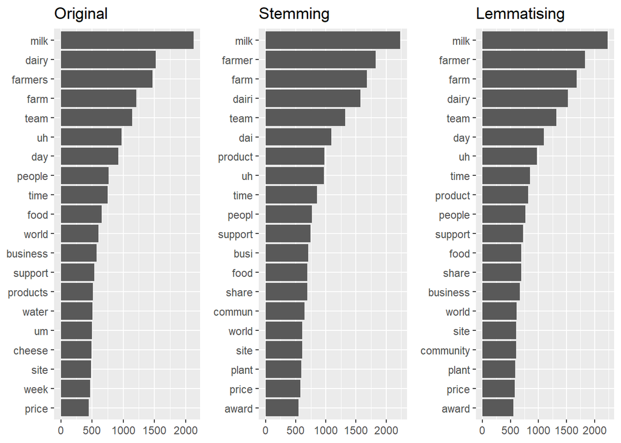

```r
# Unigram
## Stem and lemmatise words
uni_sl <- uni_clean |>
  mutate(uni_stem = stem_words(word),
         uni_lemma = lemmatize_words(word))

## Comparison of the original, stemmed, and lemmatised forms
g1 <- uni_sl |>
  count(word, sort = TRUE) |>
  slice_max(order_by = n, n = 20) |>
  ggplot(aes(x = n, y = reorder(word, n))) +
  geom_col() +
  labs(title = "Original", x = NULL, y = NULL)

g2 <- uni_sl |>
  count(uni_stem, sort = TRUE) |>
  slice_max(order_by = n, n = 20) |>
  ggplot(aes(x = n, y = reorder(uni_stem, n))) +
  geom_col() +
  labs(title = "Stemming", x = NULL, y = NULL)

g3 <- uni_sl |>
  count(uni_lemma, sort = TRUE) |>
  slice_max(order_by = n, n = 20) |>
  ggplot(aes(x = n, y = reorder(uni_lemma, n))) +
  geom_col() +
  labs(title = "Lemmatising", x = NULL, y = NULL)

grid.arrange(g1, g2, g3, ncol = 3)
```

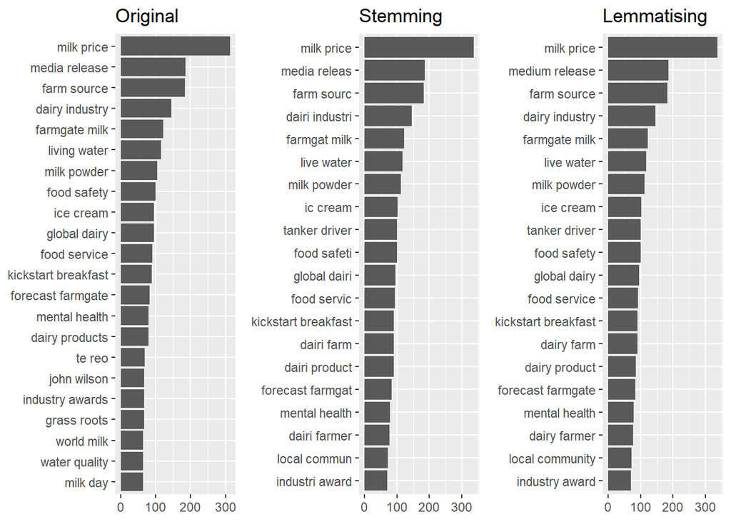

```r
## Keep lemmatised form and override object
uni_clean <- uni_sl |>
  select(-c(word, uni_stem)) |>
  rename(word = uni_lemma)

# Bigram
## Stem and lemmatise bigrams
bi_sl <- bigram_clean |>
  mutate(bigram_stem = stem_strings(bigram),
         bigram_lemma = lemmatize_strings(bigram))

## Comparison of the original, stemmed, and lemmatised forms
g4 <- bi_sl |>
  count(bigram, sort = TRUE) |>
  slice_max(order_by = n, n = 20) |>
  ggplot(aes(x = n, y = reorder(bigram, n))) +
  geom_col() +
  labs(title = "Original", x = NULL, y = NULL)

g5 <- bi_sl |>
  count(bigram_stem, sort = TRUE) |>
  slice_max(order_by = n, n = 20) |>
  ggplot(aes(x = n, y = reorder(bigram_stem, n))) +
  geom_col() +
  labs(title = "Stemming", x = NULL, y = NULL)

g6 <- bi_sl |>
  count(bigram_lemma, sort = TRUE) |>
  slice_max(order_by = n, n = 20) |>
  ggplot(aes(x = n, y = reorder(bigram_lemma, n))) +
  geom_col() +
  labs(title = "Lemmatising", x = NULL, y = NULL)

grid.arrange(g4, g5, g6, ncol = 3)
```

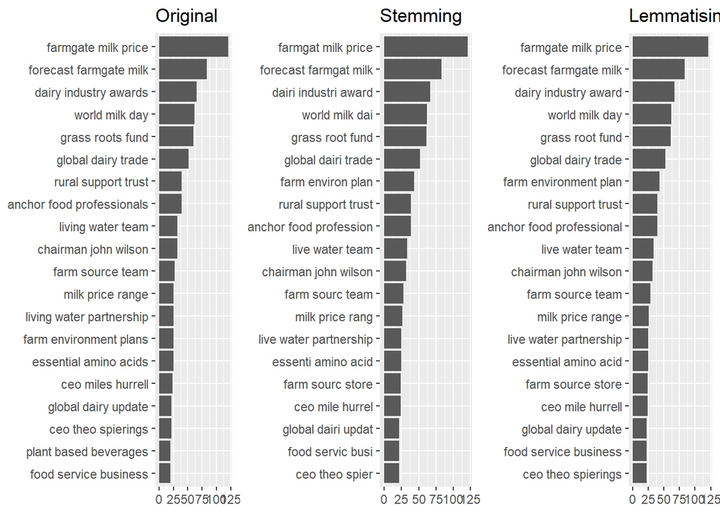

```r
## Keep lemmatised form and override object
bi_clean <- bi_sl |>
  select(-c(bigram, starts_with("word"), contains("stem"))) |>
  rename(bigram = bigram_lemma)

# Trigram
## Stem and lemmatise Trigrams
tri_sl <- trigram_clean |>
  mutate(trigram_stem = stem_strings(trigram),
         trigram_lemma = lemmatize_strings(trigram))

## Comparison of the original, stemmed, and lemmatised forms
g7 <- tri_sl |>
  count(trigram, sort = TRUE) |>
  slice_max(order_by = n, n = 20) |>
  ggplot(aes(x = n, y = reorder(trigram, n))) +
  geom_col() +
  labs(title = "Original", x = NULL, y = NULL)

g8 <- tri_sl |>
  count(trigram_stem, sort = TRUE) |>
  slice_max(order_by = n, n = 20) |>
  ggplot(aes(x = n, y = reorder(trigram_stem, n))) +
  geom_col() +
  labs(title = "Stemming", x = NULL, y = NULL)

g9 <- tri_sl |>
  count(trigram_lemma, sort = TRUE) |>
  slice_max(order_by = n, n = 20) |>
  ggplot(aes(x = n, y = reorder(trigram_lemma, n))) +
  geom_col() +
  labs(title = "Lemmatising", x = NULL, y = NULL)

grid.arrange(g7, g8, g9, ncol = 3)
```

[figure not shown]

```r
## Keep lemmatised form and override object
tri_clean <- tri_sl |>
  select(-c(trigram, starts_with("word"), contains("stem"))) |>
  rename(trigram = trigram_lemma)

# Quadgram
## Stem and lemmatise Quadgrams
quad_sl <- quadgram_clean |>
  mutate(quadgram_stem = stem_strings(quadgram),
         quadgram_lemma = lemmatize_strings(quadgram))

## Comparison of the original, stemmed, and lemmatised forms
g10 <- quad_sl |>
  count(quadgram, sort = TRUE) |>
  slice_max(order_by = n, n = 20) |>
  ggplot(aes(x = n, y = reorder(quadgram, n))) +
  geom_col() +
  labs(title = "Original", x = NULL, y = NULL)

g11 <- quad_sl |>
  count(quadgram_stem, sort = TRUE) |>
  slice_max(order_by = n, n = 20) |>
  ggplot(aes(x = n, y = reorder(quadgram_stem, n))) +
  geom_col() +
  labs(title = "Stemming", x = NULL, y = NULL)

g12 <- quad_sl |>
  count(quadgram_lemma, sort = TRUE) |>
  slice_max(order_by = n, n = 20) |>
  ggplot(aes(x = n, y = reorder(quadgram_lemma, n))) +
  geom_col() +
  labs(title = "Lemmatising", x = NULL, y = NULL)

grid.arrange(g10, g11, g12, ncol = 3)
```

[figure not shown]

```r
## Keep lemmatised form and override object
quad_clean <- quad_sl |>
  select(-c(quadgram, starts_with("word"), contains("stem"))) |>
  rename(quadgram = quadgram_lemma)

# Pentagram
## Stem and lemmatise Fivegrams
penta_sl <- pentagram_clean |>
  mutate(pentagram_stem = stem_strings(pentagram),
         pentagram_lemma = lemmatize_strings(pentagram))

## Comparison of the original, stemmed, and lemmatised forms
g13 <- penta_sl |>
  count(pentagram, sort = TRUE) |>
  slice_max(order_by = n, n = 20) |>
  ggplot(aes(x = n, y = reorder(pentagram, n))) +
  geom_col() +
  labs(title = "Original", x = NULL, y = NULL)

g14 <- penta_sl |>
  count(pentagram_stem, sort = TRUE) |>
  slice_max(order_by = n, n = 20) |>
  ggplot(aes(x = n, y = reorder(pentagram_stem, n))) +
  geom_col() +
  labs(title = "Stemming", x = NULL, y = NULL)

g15 <- penta_sl |>
  count(pentagram_lemma, sort = TRUE) |>
  slice_max(order_by = n, n = 20) |>
  ggplot(aes(x = n, y = reorder(pentagram_lemma, n))) +
  geom_col() +
  labs(title = "Lemmatising", x = NULL, y = NULL)

grid.arrange(g13, g14, g15, ncol = 3)
```

[figure not shown]

```r
## Keep lemmatised form and override object
penta_clean <- penta_sl |>
  select(-c(pentagram, starts_with("word"), contains("stem"))) |>
  rename(pentagram = pentagram_lemma)

# Hexagram
## Stem and lemmatise Sixgrams
hexa_sl <- hexagram_clean |>
  mutate(hexagram_stem = stem_strings(hexagram),
         hexagram_lemma = lemmatize_strings(hexagram))

## Comparison of the original, stemmed, and lemmatised forms
g16 <- hexa_sl |>
  count(hexagram, sort = TRUE) |>
  slice_max(order_by = n, n = 20) |>
  ggplot(aes(x = n, y = reorder(hexagram, n))) +
  geom_col() +
  labs(title = "Original", x = NULL, y = NULL)

g17 <- hexa_sl |>
  count(hexagram_stem, sort = TRUE) |>
  slice_max(order_by = n, n = 20) |>
  ggplot(aes(x = n, y = reorder(hexagram_stem, n))) +
  geom_col() +
  labs(title = "Stemming", x = NULL, y = NULL)

g18 <- hexa_sl |>
  count(hexagram_lemma, sort = TRUE) |>
  slice_max(order_by = n, n = 20) |>
  ggplot(aes(x = n, y = reorder(hexagram_lemma, n))) +
  geom_col() +
  labs(title = "Lemmatising", x = NULL, y = NULL)

grid.arrange(g16, g17, g18, ncol = 3)
```

```r
## Keep lemmatised form and override object
hexa_clean <- hexa_sl |>
  select(-c(hexagram, starts_with("word"), contains("stem"))) |>
  rename(hexagram = hexagram_lemma)


rm(g1, g2, g3, g4, g5, g6, g7, g8, g9, g10, g11, g12, g13, g14, g15, g16, g17, g18, bi_clean, ngram_list, bigram_clean, tri_clean, trigram_clean, quad_clean, quadgram_clean, penta_clean, pentagram_clean, hexa_clean, hexagram_clean)
```

# 5 5. What Topics Have Content Creators Been Posting About?

## 5.1 5.1 Term Frequency Analysis

```r
# Calculate term frequencies.
# Unigram
## Word count table
uni_sl |>
  count(uni_lemma, sort = TRUE) |>
  slice_max(n = 20, order_by = n)
```

| uni_lemma | n |
| --- | --- |
| milk | 2235 |
| farmer | 1825 |
| farm | 1679 |
| dairy | 1526 |
| team | 1322 |
| day | 1094 |
| uh | 970 |
| time | 846 |
| product | 813 |
| people | 767 |
| support | 727 |
| food | 695 |
| share | 691 |
| business | 670 |
| world | 607 |
| site | 604 |
| community | 600 |
| plant | 583 |
| price | 575 |
| award | 549 |

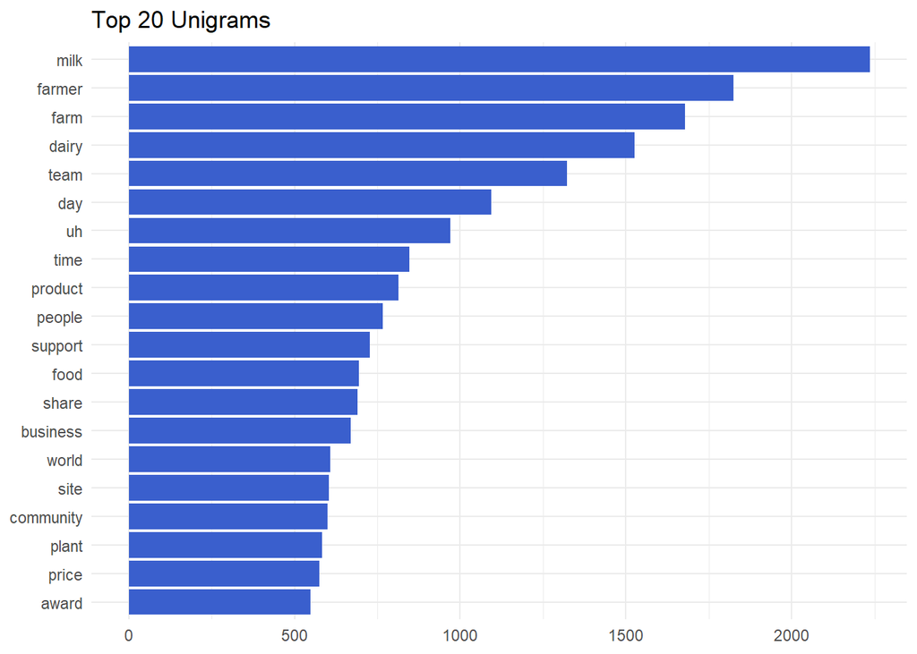

```r
## Ordered bar chart
uni_sl |>
  count(uni_lemma, sort = TRUE) |>
  slice_max(n = 20, order_by = n) |>
  ggplot(aes(x = n, y = reorder(uni_lemma, n))) +
  geom_col(fill = "royalblue3") +
  labs(title = "Top 20 Unigrams",  x = NULL,  y = NULL) +
  theme_minimal()
```

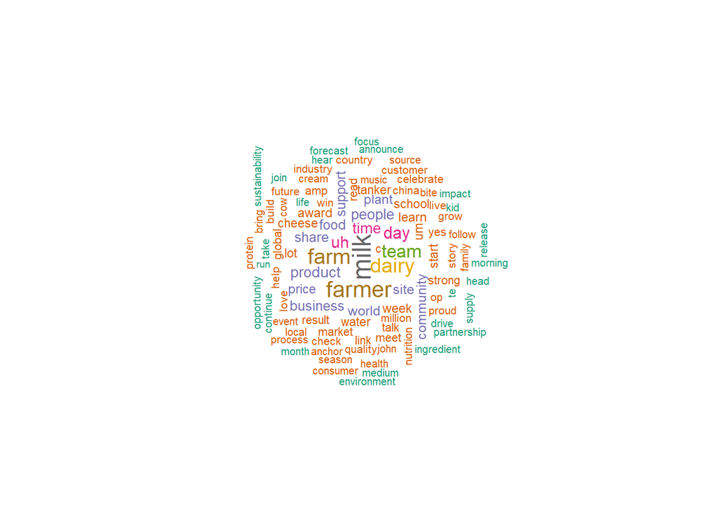

```r
## Wordcloud
uni_sl |>
  group_by(uni_lemma) |>
  summarise(count = n()) |>
  with(wordcloud(words = uni_lemma,
                 freq = count,
                 max.words = 100,
                 rot.per = 0.2,
                 random.order = FALSE,
                 colors = brewer.pal(8, "Dark2"),
                 scale = c(1.5, 0.5)
                 ))
```

```r
# Bigram
## Word count table
bi_sl |>
  count(bigram_lemma, sort = TRUE) |>
  slice_max(n = 20, order_by = n)
```

| bigram_lemma | n |
| --- | --- |
| milk price | 337 |
| medium release | 186 |
| farm source | 183 |
| dairy industry | 146 |
| farmgate milk | 122 |
| live water | 117 |
| milk powder | 112 |
| ice cream | 102 |
| food safety | 100 |
| tanker driver | 100 |
| global dairy | 95 |
| food service | 92 |
| dairy farm | 91 |
| kickstart breakfast | 91 |
| dairy product | 86 |
| forecast farmgate | 83 |
| mental health | 79 |
| dairy farmer | 76 |
| local community | 72 |
| industry award | 70 |

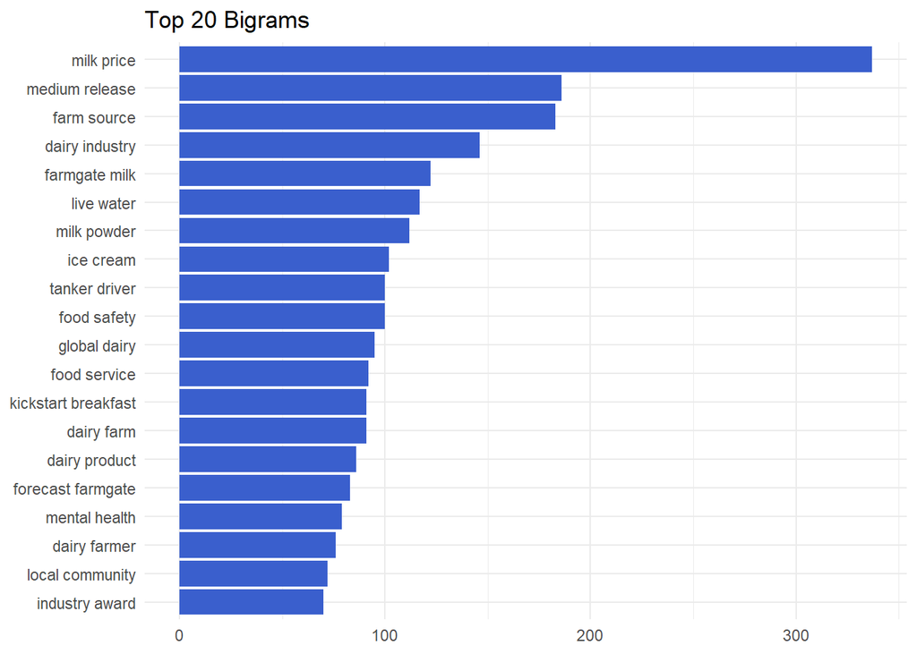

```r
## Ordered bar chart
bi_sl |>
  count(bigram_lemma, sort = TRUE) |>
  slice_max(n = 20, order_by = n) |>
  ggplot(aes(x = n, y = reorder(bigram_lemma, n))) +
  geom_col(fill = "royalblue3") +
  labs(title = "Top 20 Bigrams",  x = NULL,  y = NULL) +
  theme_minimal()
```

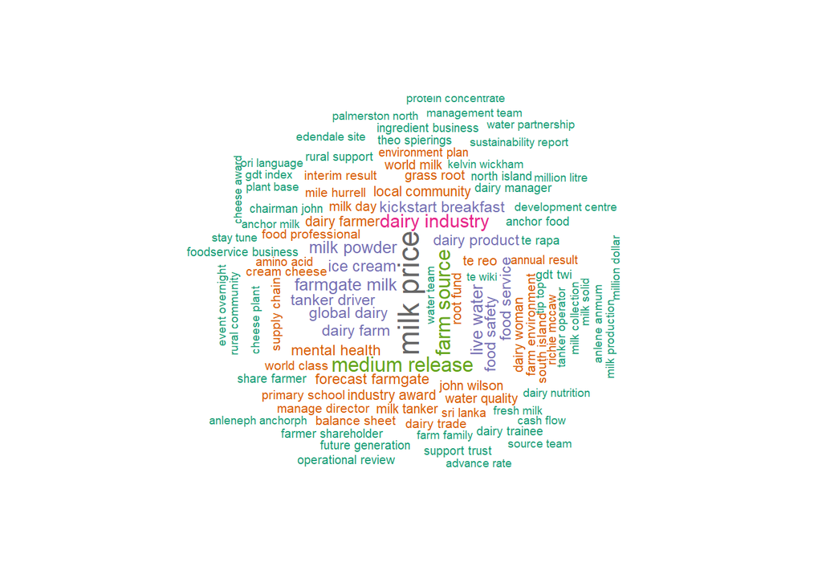

```r
## Wordcloud
bi_sl |>
  group_by(bigram_lemma) |>
  summarise(count = n()) |>
  with(wordcloud(words = bigram_lemma,
                 freq = count,
                 max.words = 100,
                 rot.per = 0.2,
                 random.order = FALSE,
                 colors = brewer.pal(8, "Dark2"),
                 scale = c(1.5, 0.5)
                 ))
```

```r
# Trigram
## Word count table
tri_sl |>
  count(trigram_lemma, sort = TRUE) |>
  slice_max(n = 20, order_by = n)
```

| trigram_lemma | n |
| --- | --- |
| farmgate milk price | 121 |
| forecast farmgate milk | 83 |
| dairy industry award | 67 |
| world milk day | 62 |
| grass root fund | 61 |
| global dairy trade | 52 |
| farm environment plan | 43 |
| anchor food professional | 39 |
| rural support trust | 39 |
| live water team | 33 |
| chairman john wilson | 32 |
| farm source team | 28 |
| milk price range | 26 |
| essential amino acid | 25 |
| live water partnership | 25 |
| ceo mile hurrell | 24 |
| farm source store | 24 |
| ceo theo spierings | 22 |
| food service business | 22 |
| global dairy update | 22 |

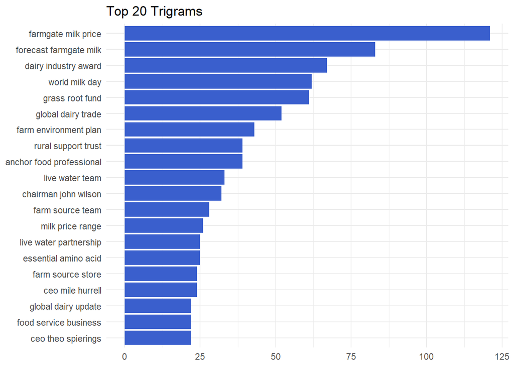

```r
## Ordered bar chart
tri_sl |>
  count(trigram_lemma, sort = TRUE) |>
  slice_max(n = 20, order_by = n) |>
  ggplot(aes(x = n, y = reorder(trigram_lemma, n))) +
  geom_col(fill = "royalblue3") +
  labs(title = "Top 20 Trigrams",  x = NULL,  y = NULL) +
  theme_minimal()
```

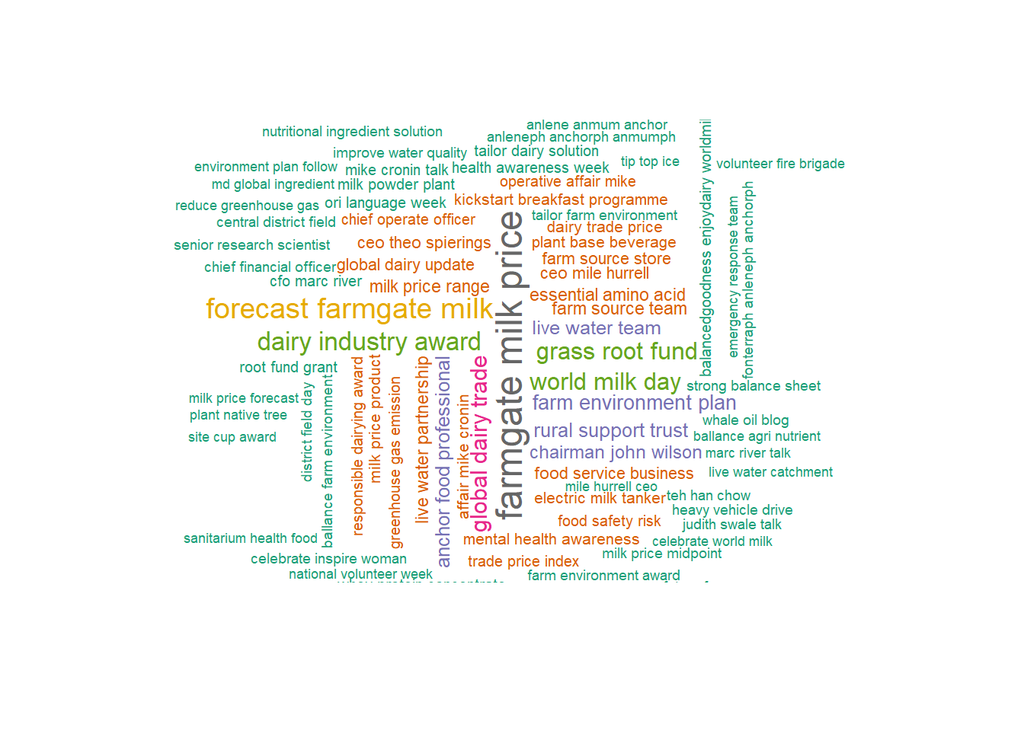

```r
## Wordcloud
tri_sl |>
  group_by(trigram_lemma) |>
  summarise(count = n()) |>
  with(wordcloud(words = trigram_lemma,
                 freq = count,
                 max.words = 100,
                 rot.per = 0.2,
                 random.order = FALSE,
                 colors = brewer.pal(8, "Dark2"),
                 scale = c(1.5, 0.5)
                 ))
```

```r
# Quadgram
## Word count table
quad_sl |>
  count(quadgram_lemma, sort = TRUE) |>
  slice_max(n = 20, order_by = n)
```

| quadgram_lemma | n |
| --- | --- |
| forecast farmgate milk price | 83 |
| farmgate milk price range | 26 |
| global dairy trade price | 18 |
| dairy trade price index | 16 |
| operative affair mike cronin | 16 |
| mental health awareness week | 15 |
| grass root fund grant | 14 |
| ballance farm environment award | 13 |
| root fund grant close | 13 |
| affair mike cronin talk | 12 |
| farmgate milk price midpoint | 12 |
| tag balancedgoodness enjoydairy worldmilkday | 12 |
| fonterraph anleneph anchorph anmumph | 11 |
| fonterraph anleneph anmumph anchorph | 11 |
| tailor farm environment plan | 11 |
| central district field day | 10 |
| season forecast farmgate milk | 10 |
| anmumph anleneph anchorph fonterraph | 9 |
| sanitarium health food company | 9 |
| celebrate world milk day | 8 |
| cfo marc river talk | 8 |
| farm environment plan follow | 8 |
| fund grant close march | 8 |
| global dairy trade auction | 8 |
| happy world milk day | 8 |
| henry van der heyden | 8 |
| tip top ice cream | 8 |

[figure not shown]

```r
## Ordered bar chart
quad_sl |>
  count(quadgram_lemma, sort = TRUE) |>
  slice_max(n = 20, order_by = n) |>
  ggplot(aes(x = n, y = reorder(quadgram_lemma, n))) +
  geom_col(fill = "royalblue3") +
  labs(title = "Top 20 Trigrams",  x = NULL,  y = NULL) +
  theme_minimal()
```

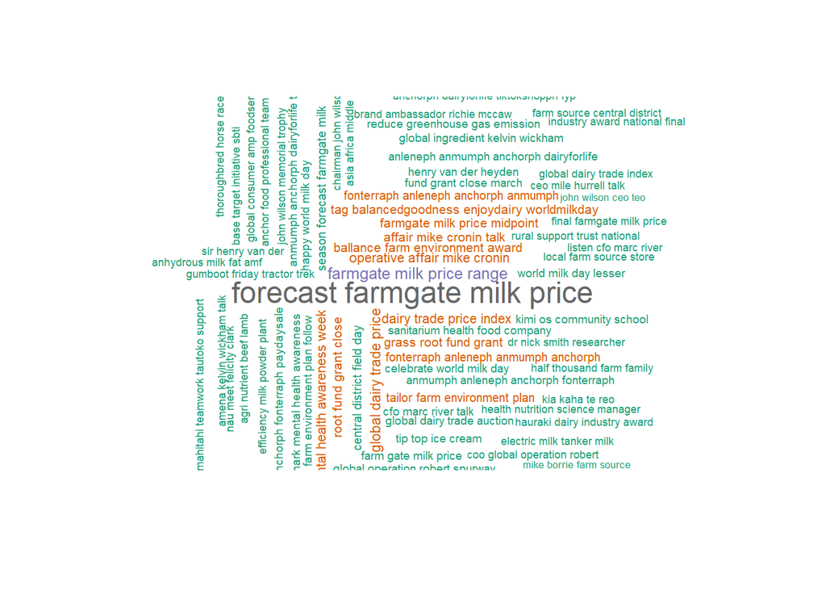

```r
## Wordcloud
quad_sl |>
  group_by(quadgram_lemma) |>
  summarise(count = n()) |>
  with(wordcloud(words = quadgram_lemma,
                 freq = count,
                 max.words = 100,
                 rot.per = 0.2,
                 random.order = FALSE,
                 colors = brewer.pal(8, "Dark2"),
                 scale = c(1.5, 0.5)
                 ))
```

```r
# Pentagram
## Word count table
penta_sl |>
  count(pentagram_lemma, sort = TRUE) |>
  slice_max(n = 20, order_by = n)
```

| pentagram_lemma | n |
| --- | --- |
| forecast farmgate milk price range | 26 |
| global dairy trade price index | 16 |
| grass root fund grant close | 13 |
| operative affair mike cronin talk | 12 |
| forecast farmgate milk price midpoint | 11 |
| season forecast farmgate milk price | 10 |
| root fund grant close march | 8 |
| anleneph anmumph anchorph dairyforlife tiktokshopph | 7 |
| anmumph anleneph anchorph fonterraph paydaysale | 7 |
| fonterraph anleneph anmumph anchorph dairyforlife | 7 |
| mark mental health awareness week | 7 |
| md global ingredient kelvin wickham | 6 |
| sir henry van der heyden | 6 |
| anmumph anchorph dairyforlife tiktokshopph fyp | 5 |
| auckland hauraki dairy industry award | 5 |
| balancedgoodness worldmilkday enjoydairy stay safe | 5 |
| coo global operation robert spurway | 5 |
| hashtag balancedgoodness worldmilkday enjoydairy stay | 5 |
| ballance agri nutrient beef lamb | 4 |
| dairy industry award national final | 4 |
| fonterraph anleneph anchorph anmumph dairyforlife | 4 |
| fonterraph anleneph anchorph anmumph tiktokshopph | 4 |
| mahitahi teamwork tautoko support whakamiha | 4 |
| science base target initiative sbti | 4 |

[figure not shown]

```r
## Ordered bar chart
penta_sl |>
  count(pentagram_lemma, sort = TRUE) |>
  slice_max(n = 20, order_by = n) |>
  ggplot(aes(x = n, y = reorder(pentagram_lemma, n))) +
  geom_col(fill = "royalblue3") +
  labs(title = "Top 20 Trigrams",  x = NULL,  y = NULL) +
  theme_minimal()
```

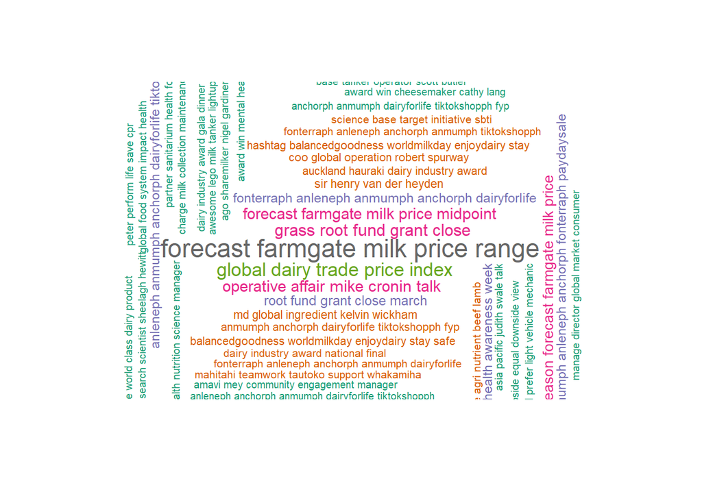

```r
## Wordcloud
penta_sl |>
  group_by(pentagram_lemma) |>
  summarise(count = n()) |>
  with(wordcloud(words = pentagram_lemma,
                 freq = count,
                 max.words = 100,
                 rot.per = 0.2,
                 random.order = FALSE,
                 colors = brewer.pal(8, "Dark2"),
                 scale = c(1.5, 0.5)
                 ))
```

```r
# Hexagram
## Word count table
hexa_sl |>
  count(hexagram_lemma, sort = TRUE) |>
  slice_max(n = 20, order_by = n)
```

| hexagram_lemma | n |
| --- | --- |
| grass root fund grant close march | 8 |
| fonterraph anleneph anmumph anchorph dairyforlife tiktokshopph | 7 |
| anleneph anmumph anchorph dairyforlife tiktokshopph fyp | 5 |
| hashtag balancedgoodness worldmilkday enjoydairy stay safe | 5 |
| season forecast farmgate milk price range | 4 |
| anleneph anchorph anmumph dairyforlife tiktokshopph fyp | 3 |
| anna palairet mcips chief operate officer | 3 |
| chairman sir henry van der heyden | 3 |
| charge milk collection maintenance efficiency cost | 3 |
| exclusive promos anmumph anleneph anchorph fonterraph | 3 |
| fonterraph anleneph anchorph anmumph dairyforlife tiktokshopph | 3 |
| health nutrition science manager maher fuad | 3 |
| hesitate peter perform life save cpr | 3 |
| junge community engagement social investment manager | 3 |
| legend dairy electric milk tanker milk | 3 |
| local rep understand milk quality animal | 3 |
| lovely picnic spot tanker driver aaron | 3 |
| maher fuad health nutrition science manager | 3 |
| mike borrie farm source regional manager | 3 |
| picnic spot tanker driver aaron burt | 3 |
| rep understand milk quality animal health | 3 |
| shaheen junge community engagement social investment | 3 |
| spot tanker driver aaron burt snap | 3 |
| stratford christmas parade spread holiday cheer | 3 |
| tanker driver chad hawksound tomorrow bring | 3 |
| week mark mental health awareness week | 3 |
| woodville fire brigade brian recently receive | 3 |

[figure not shown]

```r
## Ordered bar chart
hexa_sl |>
  count(hexagram_lemma, sort = TRUE) |>
  slice_max(n = 20, order_by = n) |>
  ggplot(aes(x = n, y = reorder(hexagram_lemma, n))) +
  geom_col(fill = "royalblue3") +
  labs(title = "Top 20 Trigrams",  x = NULL,  y = NULL) +
  theme_minimal()
```

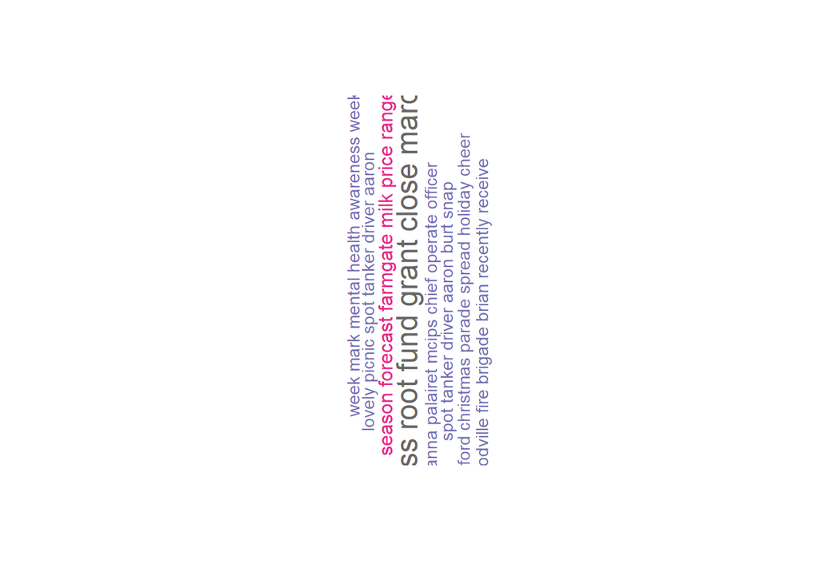

```r
## Wordcloud
hexa_sl |>
  group_by(hexagram_lemma) |>
  summarise(count = n()) |>
  with(wordcloud(words = hexagram_lemma,
                 freq = count,
                 max.words = 100,
                 rot.per = 0.2,
                 random.order = FALSE,
                 colors = brewer.pal(8, "Dark2"),
                 scale = c(1.5, 0.5)
                 ))
```

## 5.2 5.2 Topic Modelling

A Latent Dirichlet Allocation (LDA) model with six topics is fitted as an initial model, following the assignment guidance.

```r
# Prepare a document-term matrix for topic modelling.
# Documents with no remaining tokens are excluded from the model.
document_terms <- uni_clean |>
  count(document, word, sort = FALSE)

documents_with_tokens <- document_terms |>
  distinct(document)

dtm <- document_terms |>
  cast_dtm(document, word, n)

dim(dtm)
```

```
## [1]  8906 13339
```

```r
# Fit an LDA model with six topics.
set.seed(1234)

lda_model <- LDA(
  dtm,
  k = 6,
  control = list(seed = 1234)
)

lda_model
```

```
## A LDA_VEM topic model with 6 topics.
```

### 5.2.1 5.2.1 Most probable words for each topic

```r
# Extract word probabilities for each topic.
topic_terms <- tidy(lda_model, matrix = "beta")

# Display the ten highest-probability words for each topic.
top_topic_words <- topic_terms |>
  group_by(topic) |>
  slice_max(beta, n = 10, with_ties = FALSE) |>
  arrange(topic, desc(beta))|>
  ungroup()

kable(
  top_topic_words,
  digits = 4,
  caption = "Top ten words by probability for each topic"
)
```

Top ten words by probability for each topic

| topic | term | beta |
| --- | --- | --- |
| 1 | water | 0.0182 |
| 1 | uh | 0.0174 |
| 1 | um | 0.0127 |
| 1 | lot | 0.0120 |
| 1 | farm | 0.0109 |
| 1 | plant | 0.0105 |
| 1 | people | 0.0102 |
| 1 | product | 0.0098 |
| 1 | time | 0.0096 |
| 1 | farmer | 0.0092 |
| 2 | milk | 0.0242 |
| 2 | price | 0.0177 |
| 2 | farmer | 0.0153 |
| 2 | uh | 0.0148 |
| 2 | business | 0.0135 |
| 2 | result | 0.0127 |
| 2 | market | 0.0105 |
| 2 | china | 0.0102 |
| 2 | john | 0.0086 |
| 2 | million | 0.0082 |
| 3 | team | 0.0174 |
| 3 | milk | 0.0147 |
| 3 | c | 0.0144 |
| 3 | amp | 0.0136 |
| 3 | day | 0.0122 |
| 3 | cheer | 0.0097 |
| 3 | ri | 0.0093 |
| 3 | hey | 0.0083 |
| 3 | em | 0.0075 |
| 3 | worldmilkday | 0.0070 |
| 4 | team | 0.0170 |
| 4 | community | 0.0157 |
| 4 | school | 0.0142 |
| 4 | support | 0.0138 |
| 4 | farmer | 0.0137 |
| 4 | award | 0.0130 |
| 4 | dairy | 0.0113 |
| 4 | day | 0.0109 |
| 4 | tanker | 0.0083 |
| 4 | kid | 0.0074 |
| 5 | milk | 0.0251 |
| 5 | farm | 0.0247 |
| 5 | dairy | 0.0216 |
| 5 | farmer | 0.0128 |
| 5 | product | 0.0085 |
| 5 | site | 0.0085 |
| 5 | food | 0.0078 |
| 5 | plant | 0.0076 |
| 5 | world | 0.0074 |
| 5 | learn | 0.0073 |
| 6 | cheese | 0.0199 |
| 6 | farm | 0.0139 |
| 6 | cream | 0.0118 |
| 6 | te | 0.0096 |
| 6 | dairy | 0.0094 |
| 6 | story | 0.0085 |
| 6 | ori | 0.0077 |
| 6 | share | 0.0070 |
| 6 | day | 0.0070 |
| 6 | award | 0.0066 |

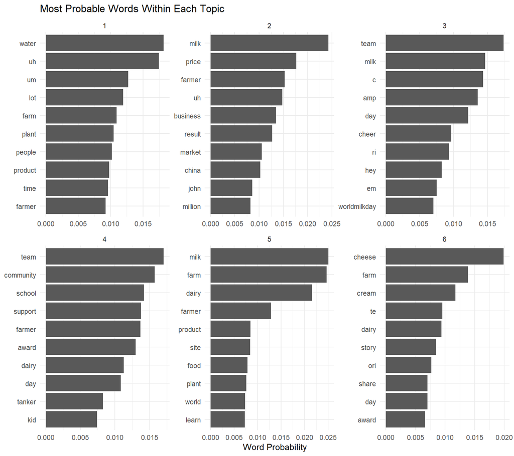

```r
# Visualise the most probable words for each topic.
top_topic_words |>
  mutate(
    plot_term = reorder_within(term, beta, topic)
  ) |>
  ggplot(aes(x = plot_term, y = beta)) +
  geom_col() +
  facet_wrap(~ topic, scales = "free") +
  coord_flip() +
  scale_x_reordered() +
  labs(
    title = "Most Probable Words Within Each Topic",
    x = NULL,
    y = "Word Probability"
  ) +
  theme_minimal()
```

** Observation:** Figure shows the most probable words associated with each of the six topics identified through the topic modelling analysis. The horizontal bars represent the estimated probability of each word within its corresponding topic, with longer bars indicating a stronger association with the topic.

Topic 1: water, farm(er), people, product(s) — farming/sustainability themed

Topic 2: milk, farmer, business, million, china — financial/milk-price themed

Topic 5: milk, farm, product, food — production themed

Topic 6: cheese, cream, dairy, share, award — consumer product themed

```r
# Keep only transformed 'data' object
rm(list = setdiff(ls(), "data"))
```

# 6 6. User Engagement Analysis

## 6.1 6.1 Exploratory data analysis

```r
# Data preparation

fonterra <- data |>
  mutate(
    platform  = factor(platform),
    media_type  = factor(media_type,
                         levels = c("No media recorded", "Image", "Sidecar", "Video")),
    day_of_week = factor(day_of_week,
                         levels = c("Mon","Tue","Wed","Thu","Fri","Sat","Sun")),
    month = factor(month, levels = month.abb),

# Extra analysis variables
log_engagement = log1p(social_engagement),
engagement_level = factor(
  if_else(social_engagement > median(social_engagement),
          "High", "Low"),
  levels = c("Low", "High")),

media_present = factor(
  has_media, levels = c(FALSE, TRUE),
  labels = c("No media", "Has media")),

video_post    = factor(
  is_video, levels = c(FALSE, TRUE),
  labels = c("Not video", "Video")),

day_type  = factor(
  if_else(day_of_week %in% c("Sat","Sun"), "Weekend", "Weekday"),
  levels = c("Weekday", "Weekend")),

# Replies on X start with an @mention (customer-service style replies)

is_reply = factor(
  str_detect(coalesce(text, ""), "^@"),
  levels = c(FALSE, TRUE),
  labels = c("Original post", "Reply"))
  )

glimpse(fonterra)
```

```
## Rows: 9,001
## Columns: 27
## $ platform              <fct> Twitter/X, Twitter/X, Twitter/X, Twitter/X, Twit…
## $ url                   <chr> "https://x.com/Fonterra/status/18915737805579880…
## $ createdAt             <chr> "2025/02/17 19:41:47", "2024/12/05 22:23:33", "2…
## $ text                  <chr> "Today we announced new incentives to help farms…
## $ media                 <fct> NA, NA, NA, NA, NA, NA, NA, NA, NA, NA, NA, NA, …
## $ commentCount          <int> 66, 1, 1, 303, 8, 2, 2, 0, 2, 0, 1, 1, 1, 0, 0, …
## $ shareCount            <int> 2, 0, 0, 102, 3, 0, 0, 0, 2, 0, 2, 0, 0, 0, 0, 1…
## $ likeCount             <int> 15, 0, 0, 704, 16, 1, 6, 0, 19, 0, 16, 1, 3, 18,…
## $ videoplayCount        <int> NA, NA, NA, NA, NA, NA, NA, NA, NA, NA, NA, NA, …
## $ created_datetime      <dttm> 2025-02-17 19:41:47, 2024-12-05 22:23:33, 2024-…
## $ year                  <dbl> 2025, 2024, 2024, 2024, 2024, 2024, 2024, 2024, …
## $ month                 <ord> Feb, Dec, Dec, Dec, Nov, Oct, Oct, Oct, Sep, Sep…
## $ day_of_week           <ord> Mon, Thu, Thu, Sun, Sun, Thu, Wed, Wed, Sun, Sat…
## $ media_type            <fct> No media recorded, No media recorded, No media r…
## $ social_engagement     <dbl> 83, 1, 1, 1109, 27, 3, 8, 0, 23, 0, 19, 2, 4, 18…
## $ has_video_plays       <lgl> FALSE, FALSE, FALSE, FALSE, FALSE, FALSE, FALSE,…
## $ has_media             <lgl> FALSE, FALSE, FALSE, FALSE, FALSE, FALSE, FALSE,…
## $ text_clean_for_length <chr> "Today we announced new incentives to help farms…
## $ text_length           <int> 365, 124, 156, 129, 251, 265, 307, 300, 255, 351…
## $ word_count            <int> 50, 22, 27, 24, 41, 44, 47, 53, 34, 62, 32, 34, …
## $ is_video              <lgl> FALSE, FALSE, FALSE, FALSE, FALSE, FALSE, FALSE,…
## $ log_engagement        <dbl> 4.4308168, 0.6931472, 0.6931472, 7.0121153, 3.33…
## $ engagement_level      <fct> High, Low, Low, High, High, Low, High, Low, High…
## $ media_present         <fct> No media, No media, No media, No media, No media…
## $ video_post            <fct> Not video, Not video, Not video, Not video, Not …
## $ day_type              <fct> Weekday, Weekday, Weekday, Weekend, Weekend, Wee…
## $ is_reply              <fct> Original post, Reply, Reply, Original post, Orig…
```

### 6.1.1 6.1.1 Descriptive statistics

```r
fonterra |>
  select(commentCount, shareCount, likeCount, videoplayCount, social_engagement, text_length, word_count) |>
  tbl_summary(
    type = all_continuous() ~ "continuous2",
    statistic = all_continuous() ~ c("{mean} ({sd})",
                                     "{median} ({p25}, {p75})",
                                     "{min}, {max}"),
    missing_text = "Missing"
  ) |>
  bold_labels()
```

| **Characteristic** | **N = 9,001** |
| --- | --- |
| commentCount |  |
| Mean (SD) | 8 (100) |
| Median (Q1, Q3) | 0 (0, 1) |
| Min, Max | 0, 4,265 |
| Missing | 293 |
| shareCount |  |
| Mean (SD) | 4 (27) |
| Median (Q1, Q3) | 1 (0, 3) |
| Min, Max | 0, 1,621 |
| Missing | 951 |
| likeCount |  |
| Mean (SD) | 48 (197) |
| Median (Q1, Q3) | 3 (0, 20) |
| Min, Max | 0, 9,528 |
| videoplayCount |  |
| Mean (SD) | 32,998 (104,613) |
| Median (Q1, Q3) | 2,784 (498, 11,532) |
| Min, Max | 20, 1,199,468 |
| Missing | 8,115 |
| social_engagement |  |
| Mean (SD) | 60 (272) |
| Median (Q1, Q3) | 5 (1, 25) |
| Min, Max | 0, 11,819 |
| text_length |  |
| Mean (SD) | 292 (1,061) |
| Median (Q1, Q3) | 140 (109, 239) |
| Min, Max | 0, 39,378 |
| word_count |  |
| Mean (SD) | 48 (198) |
| Median (Q1, Q3) | 22 (16, 37) |
| Min, Max | 0, 7,335 |

```r
fonterra |>
  select(platform, social_engagement, likeCount, commentCount, shareCount, text_length, media_type, day_type) |>
  tbl_summary(
    by = platform,
    statistic = list(all_continuous() ~ "{median} ({p25}, {p75})", all_categorical() ~ "{n} ({p}%)"),
    missing = "no"
  ) |>
  add_overall() |>
  bold_labels()
```

| **Characteristic** | **Overall** N = 9,001<sup>1</sup> | **Facebook** N = 1,433<sup>1</sup> | **Instagram** N = 519<sup>1</sup> | **LinkedIn** N = 326<sup>1</sup> | **TikTok** N = 108<sup>1</sup> | **Twitter/X** N = 6,220<sup>1</sup> | **YouTube** N = 395<sup>1</sup> |
| --- | --- | --- | --- | --- | --- | --- | --- |
| social_engagement | 5 (1, 25) | 74 (26, 194) | 134 (78, 199) | 149 (91, 246) | 10 (5, 18) | 2 (1, 7) | 0 (0, 4) |
| likeCount | 3 (0, 20) | 61 (23, 157) | 132 (76, 194) | 141 (84, 226) | 7 (4, 12) | 1 (0, 5) | 0 (0, 4) |
| commentCount | 0 (0, 1) | 7 (2, 25) | 2 (0, 4) | 5 (2, 9) | 0 (0, 1) | 0 (0, 1) | 0 (0, 0) |
| shareCount | 1 (0, 3) | 4 (1, 12) | NA (NA, NA) | 4 (2, 6) | 2 (1, 5) | 0 (0, 2) | NA (NA, NA) |
| text_length | 140 (109, 239) | 213 (129, 321) | 254 (176, 361) | 708 (454, 958) | 254 (205, 312) | 133 (98, 155) | 1,160 (518, 2,292) |
| media_type |  |  |  |  |  |  |  |
| No media recorded | 6,994 (78%) | 680 (47%) | 0 (0%) | 94 (29%) | 0 (0%) | 6,220 (100%) | 0 (0%) |
| Image | 930 (10%) | 435 (30%) | 301 (58%) | 194 (60%) | 0 (0%) | 0 (0%) | 0 (0%) |
| Sidecar | 95 (1.1%) | 0 (0%) | 95 (18%) | 0 (0%) | 0 (0%) | 0 (0%) | 0 (0%) |
| Video | 982 (11%) | 318 (22%) | 123 (24%) | 38 (12%) | 108 (100%) | 0 (0%) | 395 (100%) |
| day_type |  |  |  |  |  |  |  |
| Weekday | 7,725 (86%) | 1,243 (87%) | 443 (85%) | 297 (91%) | 97 (90%) | 5,301 (85%) | 344 (87%) |
| Weekend | 1,276 (14%) | 190 (13%) | 76 (15%) | 29 (8.9%) | 11 (10%) | 919 (15%) | 51 (13%) |

<sup>1</sup> Median (Q1, Q3); n (%)

```r
tibble(
  `Posts with zero engagement` =
    percent(mean(fonterra$social_engagement == 0), 0.1),
  `Skewness of engagement`  =
    round(datawizard::skewness(fonterra$social_engagement)$Skewness, 1),
  `Mean`   = round(mean(fonterra$social_engagement), 1),
  `Median` = median(fonterra$social_engagement))|>
  gt()
```

| Posts with zero engagement | Skewness of engagement | Mean | Median |
| --- | --- | --- | --- |
| 16.4% | 19.1 | 59.8 | 5 |

### 6.1.2 6.1.3 Distribution of engagement

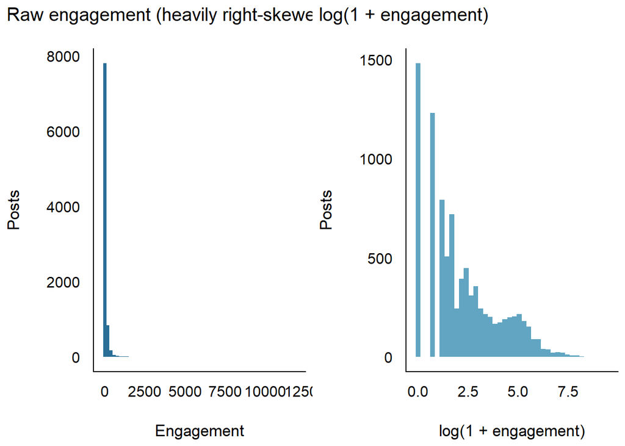

```r
p1 <- ggplot(fonterra, aes(social_engagement)) +
  geom_histogram(bins = 60, fill = "#2a6f97") +
  labs(title = "Raw engagement (heavily right-skewed)", x = "Engagement", y = "Posts") +
  theme_modern()

p2 <- ggplot(fonterra, aes(log_engagement)) +
  geom_histogram(bins = 40, fill = "#61a5c2") +
  labs(title = "log(1 + engagement)", x = "log(1 + engagement)", y = "Posts") +
  theme_modern()

grid.arrange(p1, p2, ncol = 2)
```

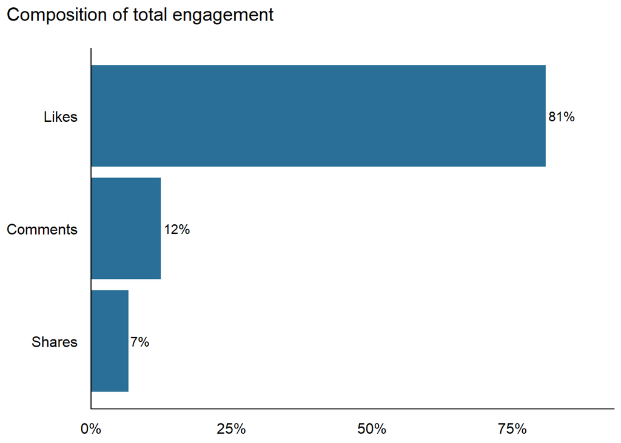

```r
fonterra |>
  summarise(Likes = sum(likeCount, na.rm = TRUE),
            Comments = sum(commentCount, na.rm = TRUE),
            Shares = sum(shareCount, na.rm = TRUE)) |>
  pivot_longer(everything(), names_to = "type", values_to = "total") |>
  mutate(share = total / sum(total)) |>
  ggplot(aes(reorder(type, share), share)) +
  geom_col(fill = "#2a6f97") +
  geom_text(aes(label = percent(share, 1)), hjust = -0.1) +
  coord_flip() +
  scale_y_continuous(labels = percent, expand = expansion(mult = c(0, 0.15))) +
  labs(title = "Composition of total engagement", x = NULL, y = NULL) +
  theme_modern()
```

### 6.1.3 6.1.4 Platform: volume versus engagement

```r
platform_summary <- fonterra |>
  group_by(platform) |>
  summarise(posts = n(),
            total_eng = sum(social_engagement),
            mean_eng = mean(social_engagement),
            median_eng = median(social_engagement),
            .groups = "drop") |>
  mutate(share_posts = posts / sum(posts),
         share_eng   = total_eng / sum(total_eng))

platform_summary |>
  arrange(desc(median_eng)) |>
  gt() |>
  fmt_number(c(mean_eng, median_eng), decimals = 1) |>
  fmt_percent(c(share_posts, share_eng), decimals = 1) |>
  tab_header(title = "Platform summary")
```

Platform summary

| platform | posts | total_eng | mean_eng | median_eng | share_posts | share_eng |
| --- | --- | --- | --- | --- | --- | --- |
| LinkedIn | 326 | 68316 | 209.6 | 148.5 | 3.6% | 12.7% |
| Instagram | 519 | 78238 | 150.7 | 134.0 | 5.8% | 14.5% |
| Facebook | 1433 | 342752 | 239.2 | 74.0 | 15.9% | 63.7% |
| TikTok | 108 | 4962 | 45.9 | 10.0 | 1.2% | 0.9% |
| Twitter/X | 6220 | 40828 | 6.6 | 2.0 | 69.1% | 7.6% |
| YouTube | 395 | 3211 | 8.1 | 0.0 | 4.4% | 0.6% |

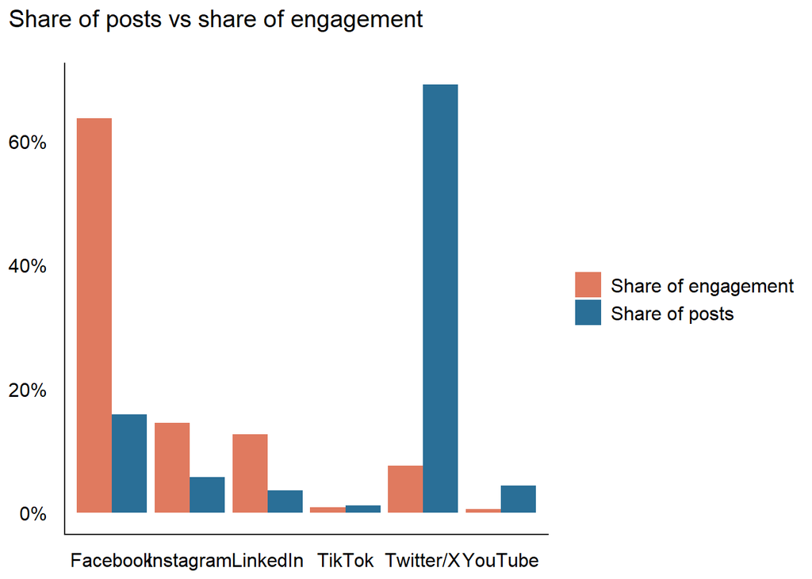

```r
platform_summary |>
  select(platform, `Share of posts` = share_posts, `Share of engagement` = share_eng) |>
  pivot_longer(-platform) |>
  ggplot(aes(platform, value, fill = name)) +
  geom_col(position = "dodge") +
  scale_y_continuous(labels = percent) +
  scale_fill_manual(values = c("#e07a5f", "#2a6f97")) +
  labs(title = "Share of posts vs share of engagement", x = NULL, y = NULL, fill = NULL) +
  theme_modern()
```

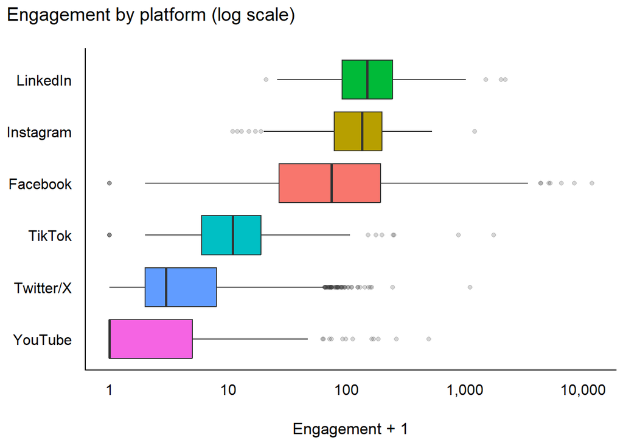

```r
ggplot(fonterra, aes(reorder(platform, social_engagement, median),
                     social_engagement + 1, fill = platform)) +
  geom_boxplot(show.legend = FALSE, outlier.alpha = 0.2) +
  scale_y_log10(labels = comma) +
  coord_flip() +
  labs(title = "Engagement by platform (log scale)", x = NULL, y = "Engagement + 1") +
  theme_modern()
```

### 6.1.4 6.1.5 Content factors: media, replies, text length

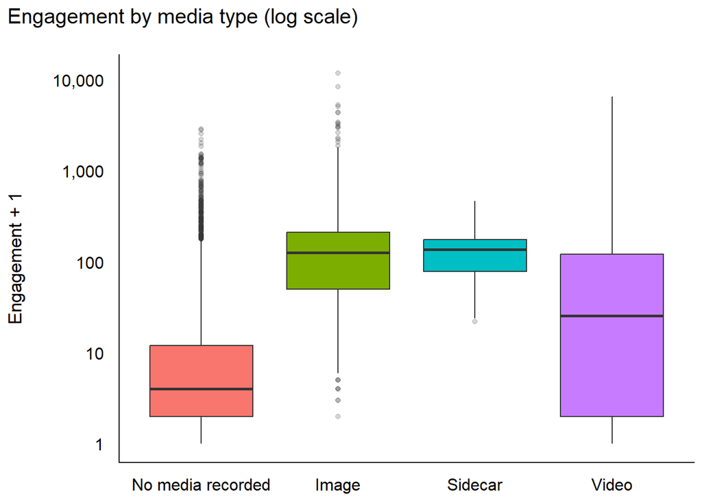

```r
ggplot(fonterra, aes(media_type, social_engagement + 1, fill = media_type)) +
  geom_boxplot(show.legend = FALSE, outlier.alpha = 0.2) +
  scale_y_log10(labels = comma) +
  labs(title = "Engagement by media type (log scale)", x = NULL, y = "Engagement + 1") +
  theme_modern()
```

```r
# Media type is confounded with platform: cross-tabulate
fonterra |>
  tbl_cross(row = platform, col = media_type, percent = "row")
```

|  | media_type No media recorded | media_type Image | media_type Sidecar | media_type Video | Total |  |
| --- | --- | --- | --- | --- | --- | --- |
| platform |  |  |  |  |  |  |
| Facebook | 680 (47%) | 435 (30%) | 0 (0%) | 318 (22%) | 1,433 (100%) |  |
| Instagram | 0 (0%) | 301 (58%) | 95 (18%) | 123 (24%) | 519 (100%) |  |
| LinkedIn | 94 (29%) | 194 (60%) | 0 (0%) | 38 (12%) | 326 (100%) |  |
| TikTok | 0 (0%) | 0 (0%) | 0 (0%) | 108 (100%) | 108 (100%) |  |
| Twitter/X | 6,220 (100%) | 0 (0%) | 0 (0%) | 0 (0%) | 6,220 (100%) |  |
| YouTube | 0 (0%) | 0 (0%) | 0 (0%) | 395 (100%) | 395 (100%) |  |
| Total | 6,994 (78%) | 930 (10%) | 95 (1.1%) | 982 (11%) | 9,001 (100%) |  |

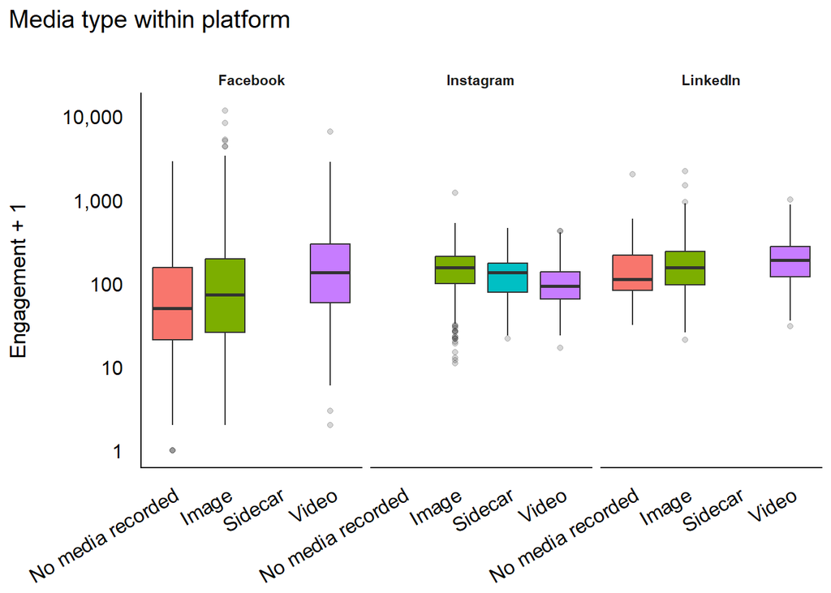

```r
# Same comparison within the platforms where media varies
fonterra |>
  filter(platform %in% c("Facebook", "LinkedIn", "Instagram")) |>
  ggplot(aes(media_type, social_engagement + 1, fill = media_type)) +
  geom_boxplot(show.legend = FALSE, outlier.alpha = 0.2) +
  scale_y_log10(labels = comma) +
  facet_wrap(~ platform) +
  labs(title = "Media type within platform", x = NULL, y = "Engagement + 1") +
  theme_modern() +
  theme(axis.text.x = element_text(angle = 30, hjust = 1))
```

```r
# Roughly 40% of X posts are @replies (customer-service style)
fonterra |>
  filter(platform == "Twitter/X") |>
  group_by(is_reply) |>
  summarise(posts = n(),
            median_eng = median(social_engagement),
            mean_eng = round(mean(social_engagement), 1)) |>
  gt() |> tab_header(title = "X: replies vs original posts")
```

X: replies vs original posts

| is_reply | posts | median_eng | mean_eng |
| --- | --- | --- | --- |
| Original post | 3708 | 5 | 10.0 |
| Reply | 2512 | 1 | 1.4 |

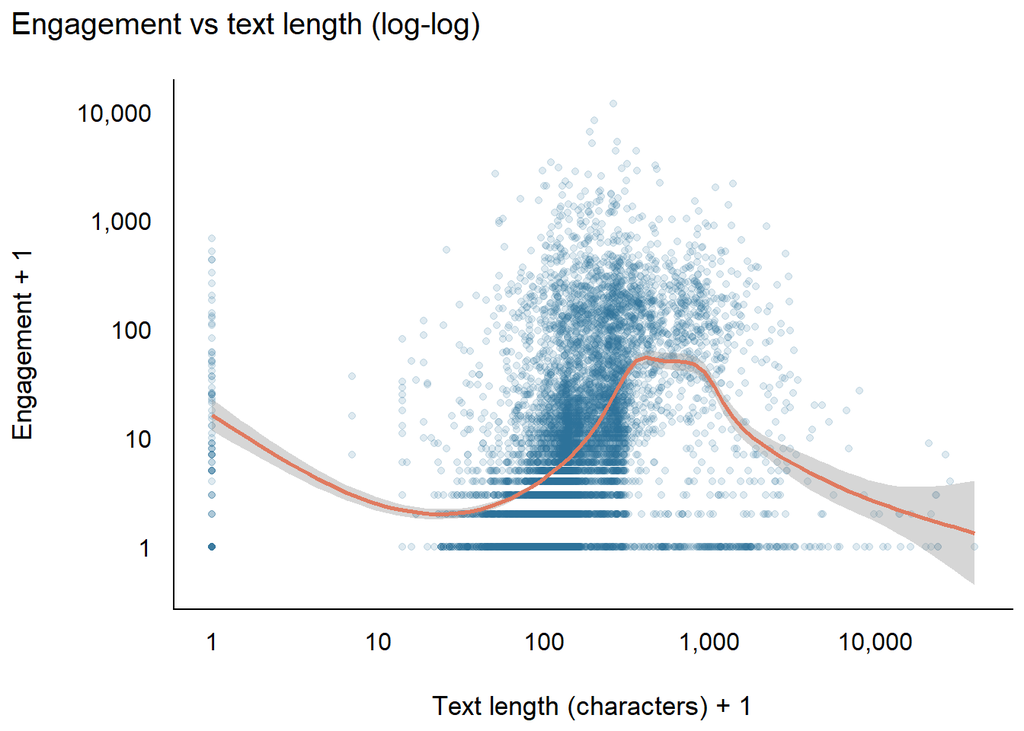

```r
ggplot(fonterra, aes(text_length + 1, social_engagement + 1)) +
  geom_point(alpha = 0.15, colour = "#2a6f97") +
  geom_smooth(method = "gam", colour = "#e07a5f") +
  scale_x_log10(labels = comma) + scale_y_log10(labels = comma) +
  labs(title = "Engagement vs text length (log-log)",
       x = "Text length (characters) + 1", y = "Engagement + 1") +
  theme_modern()
```

```r
fonterra |>
  group_by(platform) |>
  summarise(median_text_length = median(text_length),
            max_text_length = max(text_length)) |>
  gt()
```

| platform | median_text_length | max_text_length |
| --- | --- | --- |
| Facebook | 213 | 2984 |
| Instagram | 254 | 2232 |
| LinkedIn | 708 | 3038 |
| TikTok | 254 | 474 |
| Twitter/X | 133 | 936 |
| YouTube | 1160 | 39378 |

### 6.1.5 6.1.6 Time factors

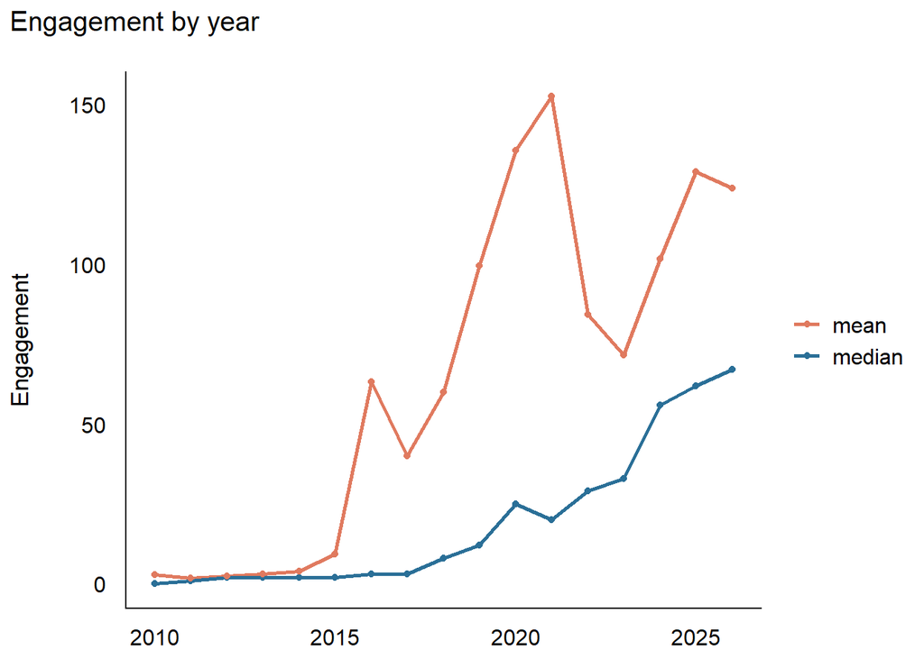

```r
fonterra |>
  group_by(year) |>
  summarise(posts = n(), median = median(social_engagement),
            mean = mean(social_engagement)) |>
  pivot_longer(c(median, mean)) |>
  ggplot(aes(year, value, colour = name)) +
  geom_line(linewidth = 1) + geom_point() +
  scale_colour_manual(values = c("#e07a5f", "#2a6f97")) +
  labs(title = "Engagement by year", x = NULL, y = "Engagement", colour = NULL) +
  theme_modern()
```

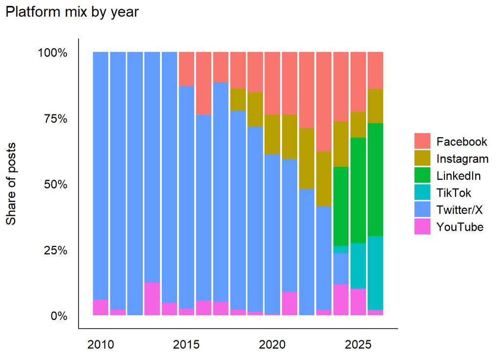

```r
# Platform mix changes over time (important confounder)
fonterra |>
  count(year, platform) |>
  ggplot(aes(year, n, fill = platform)) +
  geom_col(position = "fill") +
  scale_y_continuous(labels = percent) +
  labs(title = "Platform mix by year", x = NULL, y = "Share of posts", fill = NULL) +
  theme_modern()
```

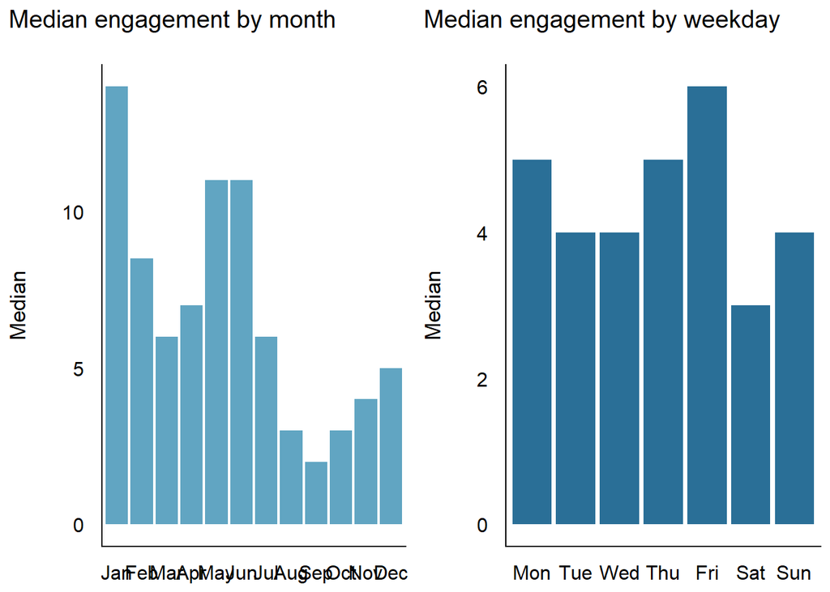

```r
p_dow <- fonterra |>
  group_by(day_of_week) |>
  summarise(median = median(social_engagement), n = n()) |>
  ggplot(aes(day_of_week, median)) +
  geom_col(fill = "#2a6f97") +
  labs(title = "Median engagement by weekday", x = NULL, y = "Median") +
  theme_modern()

p_mon <- fonterra |>
  group_by(month) |>
  summarise(median = median(social_engagement)) |>
  ggplot(aes(month, median)) +
  geom_col(fill = "#61a5c2") +
  labs(title = "Median engagement by month", x = NULL, y = "Median") +
  theme_modern()

grid.arrange(p_mon, p_dow, ncol = 2)
```

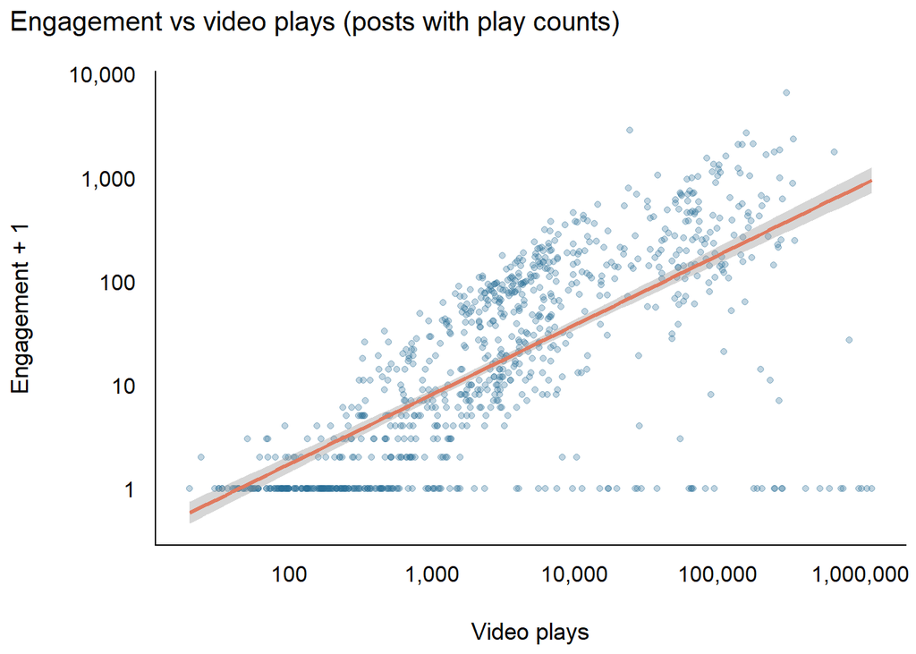

```r
fonterra |>
  filter(!is.na(videoplayCount)) |>
  ggplot(aes(videoplayCount, social_engagement + 1)) +
  geom_point(alpha = 0.3, colour = "#2a6f97") +
  geom_smooth(method = "lm", colour = "#e07a5f") +
  scale_x_log10(labels = comma) + scale_y_log10(labels = comma) +
  labs(title = "Engagement vs video plays (posts with play counts)",
       x = "Video plays", y = "Engagement + 1") +
  theme_modern()
```

```r
rm(p1, p2, p_dow, p_mon, platform_summary)
```

## 6.2 6.2 Findings

**Level of engagement.** Engagement is very unevenly distributed. Across 9,001 posts the mean is about 60 interactions but the median is only 5, with about 16% of posts receiving no engagement at all and a maximum of 11,819. The distribution is extremely right-skewed (skewness about 19), so a small number of viral posts pull the mean far above a typical post. Medians and log-transformed values are therefore the honest summary. Likes make up the large majority of interactions; comments and shares are much rarer.

**Platform.** Twitter/X supplies about 69% of posts but only about 8% of total engagement (median 2). Facebook is 16% of posts and about 64% of total engagement. Median engagement is highest on LinkedIn (about 149), Instagram (about 134) and Facebook (about 74), and lowest on YouTube (0) and X (2).

**Media.** Posts with media have far higher median engagement than text-only posts (about 81 vs 3). Media, however, is completely absent for X in this dataset, so part of this gap is a platform effect. Inside Facebook, posts with media still outperform those without (median about 99 vs 49), and video (about 135) beats images (about 72). LinkedIn shows the same direction but a smaller gap.

**Replies on X.** About 40% of X posts are @replies (customer-service style) with a median engagement of 1, compared with 5 for original posts. These dilute the apparent performance of X.

**Data caveats.** `shareCount` is entirely missing for Instagram and YouTube and `commentCount` is partly missing for Facebook and LinkedIn; `videoplayCount` exists for only 886 posts. Because `social_engagement` is built from these counts, it is understated for platforms that do not report shares. `text_length` has extreme outliers (up to about 39,000 characters), and 82 posts have no text.

# 7 7. Bivariate analysis

Engagement is heavily skewed and clearly non-normal.

## 7.1 7.1 Assumption check

```r
set.seed(1)
shapiro.test(sample(fonterra$log_engagement, 5000))
```

```
##
##  Shapiro-Wilk normality test
##
## data:  sample(fonterra$log_engagement, 5000)
## W = 0.92212, p-value < 2.2e-16
```

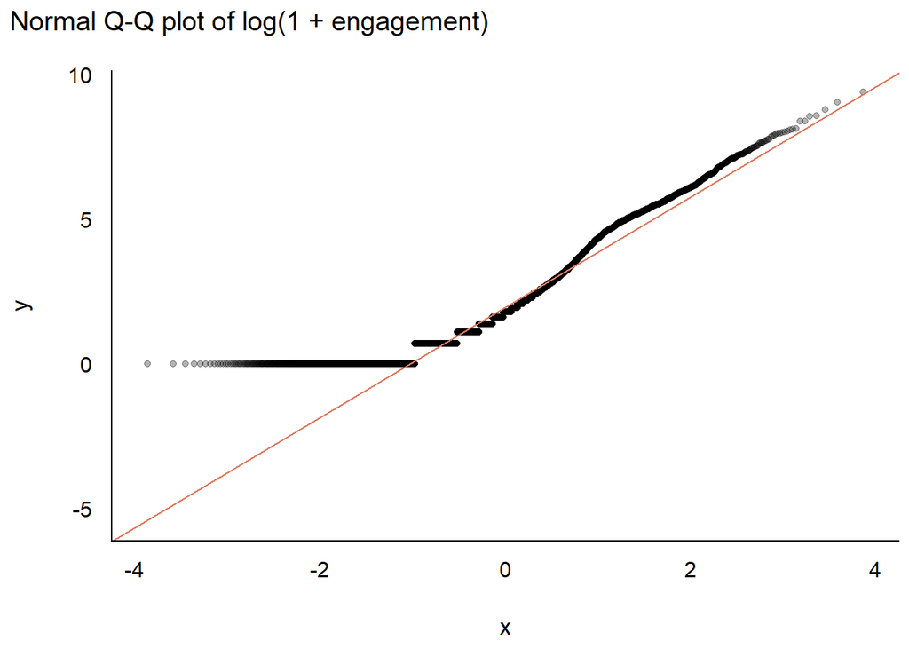

```r
ggplot(fonterra, aes(sample = log_engagement)) +
  stat_qq(alpha = 0.3) + stat_qq_line(colour = "#e07a5f") +
  labs(title = "Normal Q-Q plot of log(1 + engagement)") +
  theme_modern()
```

## 7.2 7.2 Correlation (numeric vs numeric)

```r
cor_res <- fonterra |>
  select(social_engagement, text_length, word_count, year) |>
  correlation::correlation(method = "spearman", p_adjust = "holm")

cor_res |> as_tibble() |>
  select(Parameter1, Parameter2, rho, CI_low, CI_high, p, n_Obs) |>
  gt() |> fmt_number(c(rho, CI_low, CI_high), decimals = 2) |>
  fmt_scientific(p, decimals = 1) |>
  tab_header(title = "Spearman correlations (Holm-adjusted p)")
```

Spearman correlations (Holm-adjusted p)

| Parameter1 | Parameter2 | rho | CI_low | CI_high | p | n_Obs |
| --- | --- | --- | --- | --- | --- | --- |
| social_engagement | text_length | 0.45 | 0.43 | 0.46 | 0.0 | 9001 |
| social_engagement | word_count | 0.43 | 0.41 | 0.45 | 0.0 | 9001 |
| social_engagement | year | 0.49 | 0.47 | 0.51 | 0.0 | 9001 |
| text_length | word_count | 0.95 | 0.95 | 0.96 | 0.0 | 9001 |
| text_length | year | 0.55 | 0.53 | 0.56 | 0.0 | 9001 |
| word_count | year | 0.55 | 0.54 | 0.57 | 0.0 | 9001 |

```r
# Video plays vs engagement / likes (only posts with play counts)
video_df <- fonterra |> filter(!is.na(videoplayCount))
cor.test(video_df$social_engagement, video_df$videoplayCount, method = "spearman", exact = FALSE)
```

```
##
##  Spearman's rank correlation rho
##
## data:  video_df$social_engagement and video_df$videoplayCount
## S = 30403617, p-value < 2.2e-16
## alternative hypothesis: true rho is not equal to 0
## sample estimates:
##       rho
## 0.7377135
```

```r
cor.test(video_df$likeCount,         video_df$videoplayCount, method = "spearman", exact = FALSE)
```

```
##
##  Spearman's rank correlation rho
##
## data:  video_df$likeCount and video_df$videoplayCount
## S = 31148559, p-value < 2.2e-16
## alternative hypothesis: true rho is not equal to 0
## sample estimates:
##       rho
## 0.7312871
```

```r
# Is the text-length relationship present within a single platform (X)?
x_df <- fonterra |> filter(platform == "Twitter/X")
cor.test(x_df$social_engagement, x_df$text_length, method = "spearman", exact = FALSE)
```

```
##
##  Spearman's rank correlation rho
##
## data:  x_df$social_engagement and x_df$text_length
## S = 2.3259e+10, p-value < 2.2e-16
## alternative hypothesis: true rho is not equal to 0
## sample estimates:
##       rho
## 0.4200855
```

```r
# Components of engagement
fonterra |>
  select(commentCount, shareCount, likeCount) |>
  correlation::correlation(method = "spearman", p_adjust = "holm") |>
  summary()
```

| Parameter | likeCount | shareCount |
| --- | --- | --- |
| commentCount | 0.578 | 0.383 |
| shareCount | 0.614 |  |

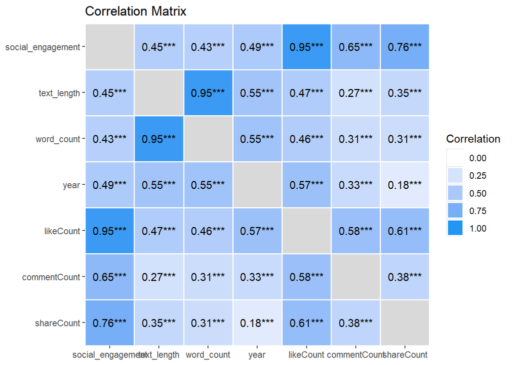

```r
fonterra |>
  select(social_engagement, text_length, word_count, year,
         likeCount, commentCount, shareCount) |>
  correlation::correlation(method = "spearman") |>
  summary(redundant = TRUE) |>
  plot()
```